# Counter projection on downstream outcomes

Kathryn Denning

6/18/2020

# Downstream outcomes impacted by counter projection - Initial Study

```r
#separating MFQ into binding and individualizing subscales
mfq_binding <- clean_data2 %>%
  filter(MFQ_Number %in% c("3", "4", "5", "9", "10", "11", "14", "15", "16",
                           "19", "20", "21", "25", "26", "27", "30", "31", "32")) %>%
  select(subid, MFQ_Number, MFQTarg, MFQSelf_c, MFQSelf, MFQStereo_c, MFQStereo, inoutgroup_effects, ident_c, par_cand, Liking, WilltoDiscuss, Valid, Treatment, Contentious) %>%
  unique() %>%
  na.omit()

mfq_individual <- clean_data2 %>%
  filter(MFQ_Number %in% c("1", "2", "7", "8", "12", "13", "17", "18", "23",
                           "24", "28", "29")) %>%
  select(subid, MFQ_Number, MFQTarg, MFQSelf_c, MFQSelf, MFQStereo_c, MFQStereo, inoutgroup_effects, ident_c, par_cand, Liking, WilltoDiscuss, Valid, Treatment, Contentious) %>%
  unique() %>%
  na.omit()
```

```r
downstream_analysis <- clean_data2 %>%
  select(subid, MFQ_Number, MFQSelf, MFQSelf_c, MFQStereo_c, MFQTarg, ident_c,
         inoutgroup_effects, par_cand, Liking, WilltoDiscuss, Contentious, Treatment, Valid, MFQStereo) %>%
  unique() %>%
  na.omit() %>%
  group_by(subid) %>%
  #getting the difference scores
  #decided to not mean center difference scores, since 0 is meaningful (no difference = 100% projection)
  mutate(proj_diff = abs(mean(MFQTarg) - mean(MFQSelf)),
         stereo_diff = abs(mean(MFQTarg)- mean(MFQStereo)))

mfq_binding_diff <- mfq_binding %>%
  group_by(subid) %>%
  mutate(proj_bind_diff = abs(mean(MFQTarg) - mean(MFQSelf)),
         stereo_bind_diff = abs(mean(MFQTarg) - mean(MFQStereo)))

mfq_individual_diff <- mfq_individual %>%
 group_by(subid) %>%
  mutate(proj_indiv_diff = abs(mean(MFQTarg) - mean(MFQStereo)),
         stereo_indiv_diff = abs(mean(MFQTarg) - mean(MFQStereo))) %>%
  na.omit()
```

## How much do you like the target?

### Overall model

```r
liking_overall <- lm(Liking ~ proj_diff*stereo_diff*inoutgroup_effects*ident_c, downstream_analysis)
summary(liking_overall)
```

```
##
## Call:
## lm(formula = Liking ~ proj_diff * stereo_diff * inoutgroup_effects *
##     ident_c, data = downstream_analysis)
##
## Residuals:
##     Min      1Q  Median      3Q     Max
## -3.4540 -0.8020  0.2304  0.7574  4.0435
##
## Coefficients:
##                                                   Estimate Std. Error t value
## (Intercept)                                       4.719954   0.021130 223.377
## proj_diff                                        -0.190032   0.034956  -5.436
## stereo_diff                                      -0.165177   0.035573  -4.643
## inoutgroup_effects                                1.663988   0.042260  39.375
## ident_c                                           0.153919   0.011369  13.539
## proj_diff:stereo_diff                             0.077122   0.045368   1.700
## proj_diff:inoutgroup_effects                     -0.123782   0.069911  -1.771
## stereo_diff:inoutgroup_effects                    0.630144   0.071146   8.857
## proj_diff:ident_c                                -0.111098   0.015032  -7.391
## stereo_diff:ident_c                               0.106644   0.018233   5.849
## inoutgroup_effects:ident_c                        0.230630   0.022737  10.143
## proj_diff:stereo_diff:inoutgroup_effects         -0.105041   0.090736  -1.158
## proj_diff:stereo_diff:ident_c                    -0.017069   0.014762  -1.156
## proj_diff:inoutgroup_effects:ident_c             -0.021255   0.030064  -0.707
## stereo_diff:inoutgroup_effects:ident_c            0.165531   0.036467   4.539
## proj_diff:stereo_diff:inoutgroup_effects:ident_c  0.003271   0.029524   0.111
##                                                              Pr(>|t|)
## (Intercept)                                      < 0.0000000000000002 ***
## proj_diff                                           0.000000055011895 ***
## stereo_diff                                         0.000003450972714 ***
## inoutgroup_effects                               < 0.0000000000000002 ***
## ident_c                                          < 0.0000000000000002 ***
## proj_diff:stereo_diff                                          0.0892 .
## proj_diff:inoutgroup_effects                                   0.0766 .
## stereo_diff:inoutgroup_effects                   < 0.0000000000000002 ***
## proj_diff:ident_c                                   0.000000000000152 ***
## stereo_diff:ident_c                                 0.000000005027905 ***
## inoutgroup_effects:ident_c                       < 0.0000000000000002 ***
## proj_diff:stereo_diff:inoutgroup_effects                       0.2470
## proj_diff:stereo_diff:ident_c                                  0.2476
## proj_diff:inoutgroup_effects:ident_c                           0.4796
## stereo_diff:inoutgroup_effects:ident_c              0.000005678979911 ***
## proj_diff:stereo_diff:inoutgroup_effects:ident_c               0.9118
## ---
## Signif. codes:  0 '***' 0.001 '**' 0.01 '*' 0.05 '.' 0.1 ' ' 1
##
## Residual standard error: 1.262 on 19882 degrees of freedom
## Multiple R-squared:  0.4223, Adjusted R-squared:  0.4219
## F-statistic: 969.1 on 15 and 19882 DF,  p-value: < 0.00000000000000022
```

### Overall model Plots

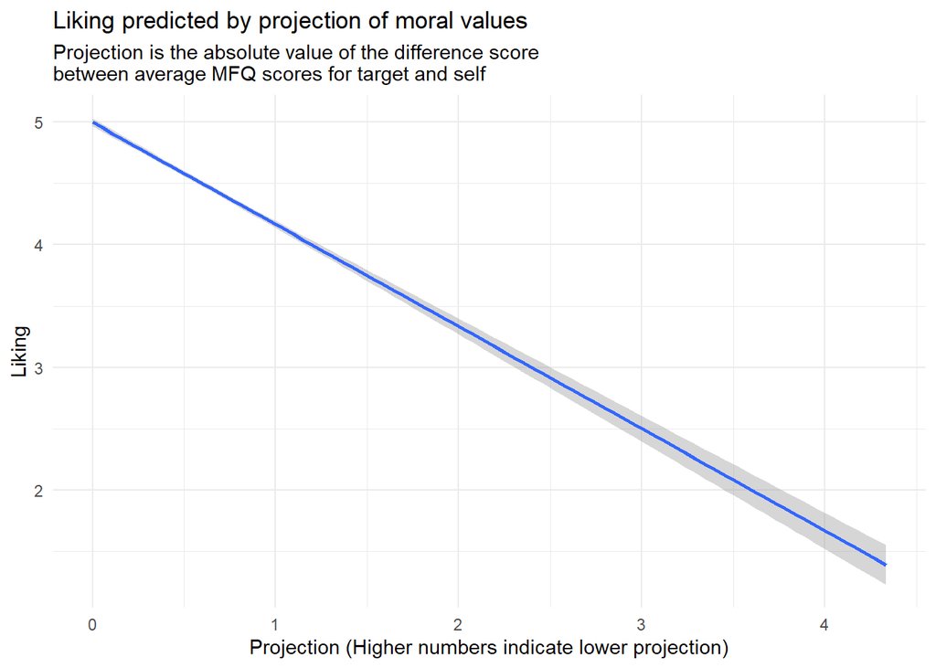

```r
#main effect of projection
ggplot(downstream_analysis, aes(proj_diff, Liking)) +
  geom_smooth(method = "lm") +
  theme_minimal() +
  labs(title = "Liking predicted by projection of moral values",
       subtitle = "Projection is the absolute value of the difference score \nbetween average MFQ scores for target and self",
       x = "Projection (Higher numbers indicate lower projection)",
       y = "Liking")
```

Counter projection can be seen as anything with a distance over 1, as that means that people are not listing their score as the same as the targets. The greater the distance demonstrates the greater the counter projection. As can be seen, as people counter project more, they report liking the target less. People who project normally report liking the target the most.

```r
#interaction between projection and degree of identification
describe(downstream_analysis$ident_c)
```

```
##    vars     n  mean   sd median trimmed mad   min  max range  skew kurtosis
## X1    1 19898 -0.03 1.78  -0.01   -0.04 1.8 -4.23 3.77     8 -0.02    -0.32
##      se
## X1 0.01
```

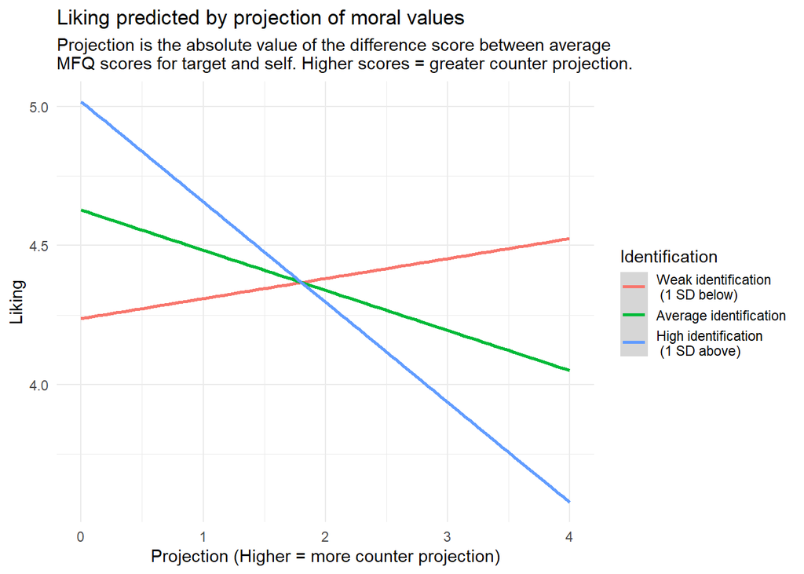

```r
liking_overall_2way <- effect(term = "proj_diff:ident_c",
                           xlevels = list(ident_c = c(-1.78, 0, 1.78)),
                           mod = liking_overall)

liking_overall_2way <- as.data.frame(liking_overall_2way)

liking_overall_2way$Identification <- as.factor(liking_overall_2way$ident_c)

ggplot(liking_overall_2way, aes(proj_diff, fit, group = Identification, color = Identification)) +
  geom_smooth(method = "lm") +
  theme_minimal() +
  scale_color_discrete("Identification", breaks = c(-1.78, 0, 1.78),
                       labels = c("Weak identification \n (1 SD below)",
                                  "Average identification",
                                  "High identification \n (1 SD above)")) +
  labs(title = "Liking predicted by projection of moral values",
       subtitle = "Projection is the absolute value of the difference score between average \nMFQ scores for target and self. Higher scores = greater counter projection.",
       x = "Projection (Higher = more counter projection)",
       y = "Liking")
```

Those who weakly identify continue to like the target, even as the distance between their scores on the MFQ and their target’s increase (becoming less similar, less projection). As in-group identification increases, self-reported liking of the target decreases as counter projection increases.

### Binding model

```r
liking_bind <- lm(Liking ~ proj_bind_diff*stereo_bind_diff*inoutgroup_effects*ident_c, mfq_binding_diff)
summary(liking_bind)
```

```
##
## Call:
## lm(formula = Liking ~ proj_bind_diff * stereo_bind_diff * inoutgroup_effects *
##     ident_c, data = mfq_binding_diff)
##
## Residuals:
##     Min      1Q  Median      3Q     Max
## -3.5388 -0.7824  0.1056  0.7848  3.5943
##
## Coefficients:
##                                                             Estimate Std. Error
## (Intercept)                                                 4.794162   0.026896
## proj_bind_diff                                             -0.090386   0.029169
## stereo_bind_diff                                            0.028208   0.030557
## inoutgroup_effects                                          1.464714   0.053792
## ident_c                                                     0.089831   0.016064
## proj_bind_diff:stereo_bind_diff                            -0.044362   0.026371
## proj_bind_diff:inoutgroup_effects                           0.139702   0.058339
## stereo_bind_diff:inoutgroup_effects                        -0.042776   0.061114
## proj_bind_diff:ident_c                                     -0.004495   0.013961
## stereo_bind_diff:ident_c                                    0.115828   0.017389
## inoutgroup_effects:ident_c                                  0.190607   0.032128
## proj_bind_diff:stereo_bind_diff:inoutgroup_effects          0.112589   0.052742
## proj_bind_diff:stereo_bind_diff:ident_c                    -0.038439   0.011566
## proj_bind_diff:inoutgroup_effects:ident_c                   0.124375   0.027921
## stereo_bind_diff:inoutgroup_effects:ident_c                 0.129997   0.034779
## proj_bind_diff:stereo_bind_diff:inoutgroup_effects:ident_c -0.064567   0.023133
##                                                            t value
## (Intercept)                                                178.249
## proj_bind_diff                                              -3.099
## stereo_bind_diff                                             0.923
## inoutgroup_effects                                          27.229
## ident_c                                                      5.592
## proj_bind_diff:stereo_bind_diff                             -1.682
## proj_bind_diff:inoutgroup_effects                            2.395
## stereo_bind_diff:inoutgroup_effects                         -0.700
## proj_bind_diff:ident_c                                      -0.322
## stereo_bind_diff:ident_c                                     6.661
## inoutgroup_effects:ident_c                                   5.933
## proj_bind_diff:stereo_bind_diff:inoutgroup_effects           2.135
```

[output cut: 29 more lines]

```
## stereo_bind_diff:inoutgroup_effects
## proj_bind_diff:ident_c
## stereo_bind_diff:ident_c                                   ***
## inoutgroup_effects:ident_c                                 ***
## proj_bind_diff:stereo_bind_diff:inoutgroup_effects         *
## proj_bind_diff:stereo_bind_diff:ident_c                    ***
## proj_bind_diff:inoutgroup_effects:ident_c                  ***
## stereo_bind_diff:inoutgroup_effects:ident_c                ***
## proj_bind_diff:stereo_bind_diff:inoutgroup_effects:ident_c **
## ---
## Signif. codes:  0 '***' 0.001 '**' 0.01 '*' 0.05 '.' 0.1 ' ' 1
##
## Residual standard error: 1.215 on 11926 degrees of freedom
## Multiple R-squared:  0.4644, Adjusted R-squared:  0.4637
## F-statistic: 689.3 on 15 and 11926 DF,  p-value: < 0.00000000000000022
```

### Binding model plots

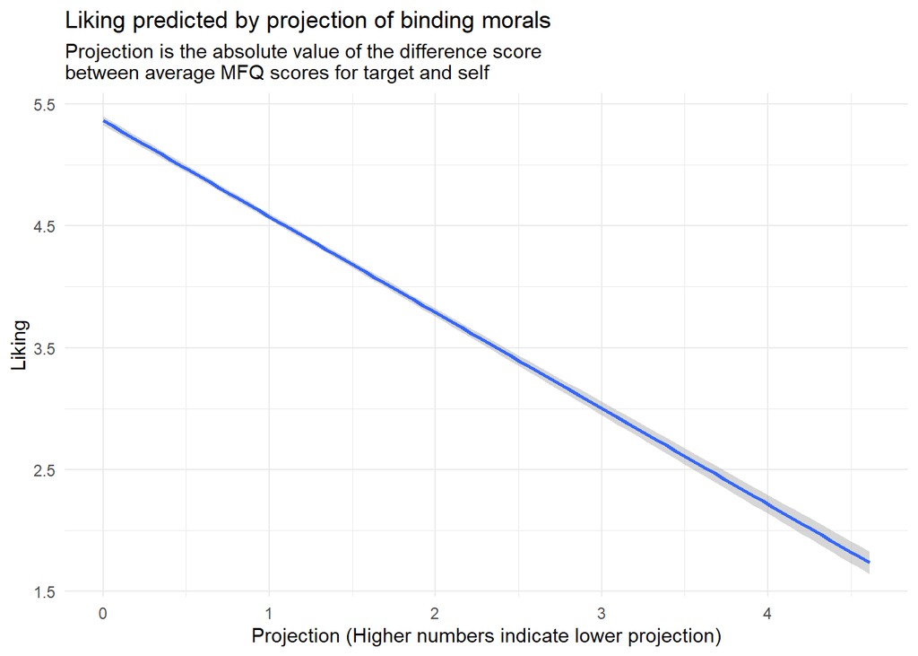

```r
#main effect of projection
ggplot(mfq_binding_diff, aes(proj_bind_diff, Liking)) +
  geom_smooth(method = "lm") +
  theme_minimal() +
  labs(title = "Liking predicted by projection of binding morals",
       subtitle = "Projection is the absolute value of the difference score \nbetween average MFQ scores for target and self",
       x = "Projection (Higher numbers indicate lower projection)",
       y = "Liking")
```

Same as overall plot.

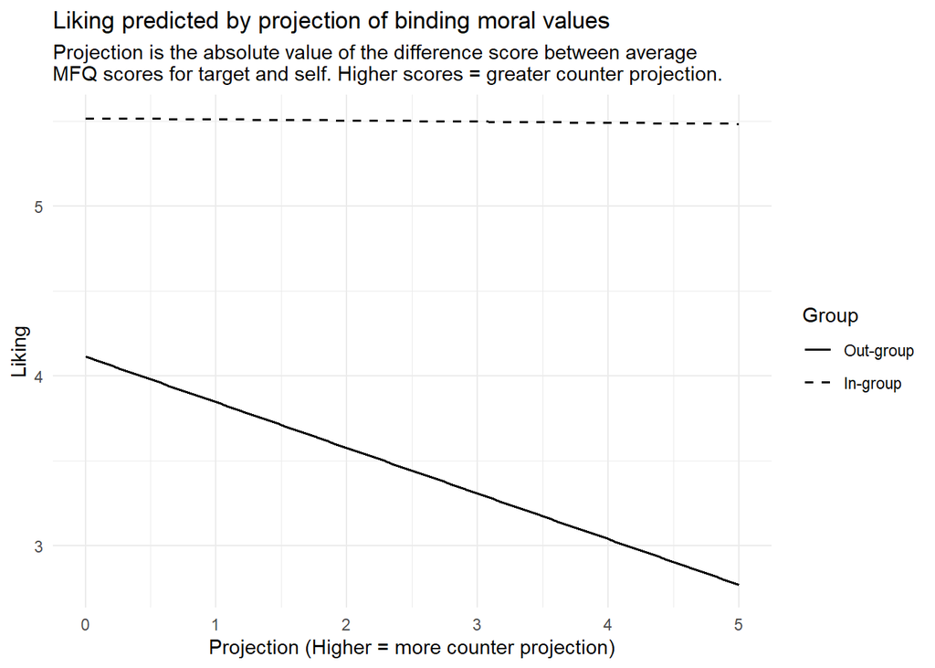

```r
liking_bind_2way_group <- effect(term = "proj_bind_diff:inoutgroup_effects",
                           xlevels = list(inoutgroup_effects = c(-.5,.5)),
                           mod = liking_bind)

liking_bind_2way_group <- as.data.frame(liking_bind_2way_group)

liking_bind_2way_group$group <- as.factor(liking_bind_2way_group$inoutgroup_effects)

ggplot(liking_bind_2way_group, aes(proj_bind_diff, fit, group = group, color = group)) +
 geom_smooth(method = "lm", se = FALSE, size = .7, colour = "black",
              aes(linetype = group)) +
  theme_minimal() +
  scale_linetype_manual("Group", breaks = c(-.5, .5),
                       labels = c("Out-group", "In-group"),
                       values = c("solid",
                                   "dashed")) +
  labs(title = "Liking predicted by projection of binding moral values",
       subtitle = "Projection is the absolute value of the difference score between average \nMFQ scores for target and self. Higher scores = greater counter projection.",
       x = "Projection (Higher = more counter projection)",
       y = "Liking")
```

Liking stays high with the in-group, regardless of their degree of projection. Liking is highest for the out-group when they are projecting. As counter projection increases (the distance becomes further), liking decreases for the out-group.

```r
describe(stereo_analysis$ident_c)
```

```
##    vars     n  mean   sd median trimmed mad   min  max range  skew kurtosis
## X1    1 20045 -0.03 1.78  -0.01   -0.04 1.8 -4.23 3.77     8 -0.02    -0.32
##      se
## X1 0.01
```

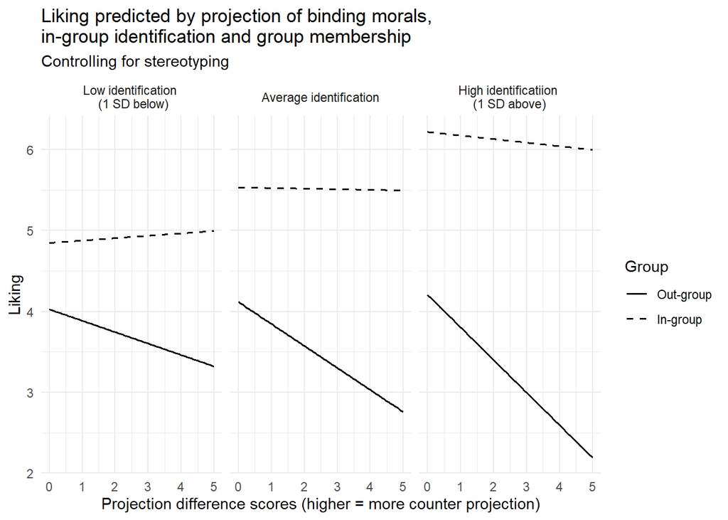

```r
binding_liking_3way <- effect(term = "proj_bind_diff:inoutgroup_effects:ident_c",
                           xlevels = list(ident_c = c(-1.78, 0, 1.78),
                                         inoutgroup_effects = c(-.5,.5)),
                           mod = liking_bind)

binding_liking_3way <- as.data.frame(binding_liking_3way)

binding_liking_3way$Group <- as.factor(binding_liking_3way$inoutgroup_effects)
binding_liking_3way$Identification <- as.factor(binding_liking_3way$ident_c)

ident_label <- c("-1.78" = "Low identification \n (1 SD below)",
                 "0" = "Average identification",
                 "1.78" = "High identificatiion \n(1 SD above)")

ggplot(binding_liking_3way, aes(proj_bind_diff,
                             fit,
                             group = Group,
                             color = Group)) +
  geom_smooth(method = "lm", se = FALSE, size = .7, colour = "black",
              aes(linetype = Group)) +
  facet_wrap(~Identification, labeller =
               labeller(Identification = ident_label)) +
  scale_linetype_manual("Group", breaks = c(-.5, .5),
                       labels = c("Out-group", "In-group"),
                       values = c("solid",
                                   "dashed")) +
  theme_minimal() +
  labs(title = "Liking predicted by projection of binding morals, \nin-group identification and group membership",
       subtitle = "Controlling for stereotyping",
       x = "Projection difference scores (higher = more counter projection)",
       y = "Liking")
```

As can be seen in the plot above, people report liking an in-group target at a similiar rate regardless of projection, while liking of the out-group target decreases as both counter projection and in-group identification increase. Thus, the people who report liking the least are considering an out-group target and are highly identified with their in-group as well as projecting their own morals the least.

### Individuating model

```r
liking_indiv <- lm(Liking ~ proj_indiv_diff*stereo_indiv_diff*inoutgroup_effects*ident_c, mfq_individual_diff)
summary(liking_indiv)
```

```
##
## Call:
## lm(formula = Liking ~ proj_indiv_diff * stereo_indiv_diff * inoutgroup_effects *
##     ident_c, data = mfq_individual_diff)
##
## Residuals:
##     Min      1Q  Median      3Q     Max
## -3.5668 -0.7639  0.1056  0.7996  3.6753
##
## Coefficients: (4 not defined because of singularities)
##                                                              Estimate
## (Intercept)                                                   4.87853
## proj_indiv_diff                                              -0.17945
## stereo_indiv_diff                                                  NA
## inoutgroup_effects                                            1.28560
## ident_c                                                       0.04418
## proj_indiv_diff:stereo_indiv_diff                            -0.08643
## proj_indiv_diff:inoutgroup_effects                            0.62506
## stereo_indiv_diff:inoutgroup_effects                               NA
## proj_indiv_diff:ident_c                                       0.25313
## stereo_indiv_diff:ident_c                                          NA
## inoutgroup_effects:ident_c                                    0.17232
## proj_indiv_diff:stereo_indiv_diff:inoutgroup_effects         -0.12613
## proj_indiv_diff:stereo_indiv_diff:ident_c                    -0.10738
## proj_indiv_diff:inoutgroup_effects:ident_c                    0.47335
## stereo_indiv_diff:inoutgroup_effects:ident_c                       NA
## proj_indiv_diff:stereo_indiv_diff:inoutgroup_effects:ident_c -0.20190
##                                                              Std. Error t value
## (Intercept)                                                     0.03012 161.976
## proj_indiv_diff                                                 0.06826  -2.629
## stereo_indiv_diff                                                    NA      NA
## inoutgroup_effects                                              0.06024  21.342
## ident_c                                                         0.01492   2.960
## proj_indiv_diff:stereo_indiv_diff                               0.03666  -2.358
## proj_indiv_diff:inoutgroup_effects                              0.13653   4.578
## stereo_indiv_diff:inoutgroup_effects                                 NA      NA
## proj_indiv_diff:ident_c                                         0.03434   7.372
## stereo_indiv_diff:ident_c                                            NA      NA
## inoutgroup_effects:ident_c                                      0.02985   5.773
## proj_indiv_diff:stereo_indiv_diff:inoutgroup_effects            0.07331  -1.720
```

[output cut: 29 more lines]

```
## stereo_indiv_diff:inoutgroup_effects
## proj_indiv_diff:ident_c                                      ***
## stereo_indiv_diff:ident_c
## inoutgroup_effects:ident_c                                   ***
## proj_indiv_diff:stereo_indiv_diff:inoutgroup_effects         .
## proj_indiv_diff:stereo_indiv_diff:ident_c                    ***
## proj_indiv_diff:inoutgroup_effects:ident_c                   ***
## stereo_indiv_diff:inoutgroup_effects:ident_c
## proj_indiv_diff:stereo_indiv_diff:inoutgroup_effects:ident_c ***
## ---
## Signif. codes:  0 '***' 0.001 '**' 0.01 '*' 0.05 '.' 0.1 ' ' 1
##
## Residual standard error: 1.206 on 7944 degrees of freedom
## Multiple R-squared:  0.4728, Adjusted R-squared:  0.4721
## F-statistic: 647.8 on 11 and 7944 DF,  p-value: < 0.00000000000000022
```

```r
linear_check <- lm(Liking ~ proj_indiv_diff*stereo_indiv_diff, mfq_individual_diff)
summary(linear_check)
```

```
##
## Call:
## lm(formula = Liking ~ proj_indiv_diff * stereo_indiv_diff, data = mfq_individual_diff)
##
## Residuals:
##     Min      1Q  Median      3Q     Max
## -4.3951 -0.9955  0.0045  1.0045  3.8465
##
## Coefficients: (1 not defined because of singularities)
##                                    Estimate Std. Error t value
## (Intercept)                        5.395091   0.031230 172.753
## proj_indiv_diff                   -0.961255   0.053442 -17.987
## stereo_indiv_diff                        NA         NA      NA
## proj_indiv_diff:stereo_indiv_diff  0.005448   0.015889   0.343
##                                              Pr(>|t|)
## (Intercept)                       <0.0000000000000002 ***
## proj_indiv_diff                   <0.0000000000000002 ***
## stereo_indiv_diff                                  NA
## proj_indiv_diff:stereo_indiv_diff               0.732
## ---
## Signif. codes:  0 '***' 0.001 '**' 0.01 '*' 0.05 '.' 0.1 ' ' 1
##
## Residual standard error: 1.439 on 7953 degrees of freedom
## Multiple R-squared:  0.2486, Adjusted R-squared:  0.2484
## F-statistic:  1315 on 2 and 7953 DF,  p-value: < 0.00000000000000022
```

Decided not to plot individuating models, as we cannot claim this is due to counter projection, as projection is the same as stereotyping in this case.

## How willing would you be to have a conversation about your political views with this person?

### Overall model output

```r
discuss_overall <- lm(WilltoDiscuss ~ proj_diff*stereo_diff*inoutgroup_effects*ident_c, downstream_analysis)
summary(discuss_overall)
```

```
##
## Call:
## lm(formula = WilltoDiscuss ~ proj_diff * stereo_diff * inoutgroup_effects *
##     ident_c, data = downstream_analysis)
##
## Residuals:
##     Min      1Q  Median      3Q     Max
## -5.0428 -1.0559  0.2463  1.0248  3.3346
##
## Coefficients:
##                                                  Estimate Std. Error t value
## (Intercept)                                       5.09481    0.02811 181.226
## proj_diff                                        -0.18734    0.04651  -4.028
## stereo_diff                                      -0.33715    0.04733  -7.123
## inoutgroup_effects                                2.15681    0.05623  38.360
## ident_c                                          -0.07428    0.01513  -4.911
## proj_diff:stereo_diff                             0.17127    0.06036   2.837
## proj_diff:inoutgroup_effects                     -0.75887    0.09302  -8.159
## stereo_diff:inoutgroup_effects                   -0.62032    0.09466  -6.553
## proj_diff:ident_c                                 0.05186    0.02000   2.593
## stereo_diff:ident_c                               0.36063    0.02426  14.866
## inoutgroup_effects:ident_c                        0.22031    0.03025   7.283
## proj_diff:stereo_diff:inoutgroup_effects          0.56341    0.12072   4.667
## proj_diff:stereo_diff:ident_c                    -0.11896    0.01964  -6.057
## proj_diff:inoutgroup_effects:ident_c             -0.08602    0.04000  -2.151
## stereo_diff:inoutgroup_effects:ident_c            0.40581    0.04852   8.364
## proj_diff:stereo_diff:inoutgroup_effects:ident_c -0.14472    0.03928  -3.684
##                                                              Pr(>|t|)
## (Intercept)                                      < 0.0000000000000002 ***
## proj_diff                                        0.000056402922172085 ***
## stereo_diff                                      0.000000000001088290 ***
## inoutgroup_effects                               < 0.0000000000000002 ***
## ident_c                                          0.000000913693464514 ***
## proj_diff:stereo_diff                                         0.00455 **
## proj_diff:inoutgroup_effects                     0.000000000000000359 ***
## stereo_diff:inoutgroup_effects                   0.000000000057695994 ***
## proj_diff:ident_c                                             0.00952 **
## stereo_diff:ident_c                              < 0.0000000000000002 ***
## inoutgroup_effects:ident_c                       0.000000000000339752 ***
## proj_diff:stereo_diff:inoutgroup_effects         0.000003076300964101 ***
## proj_diff:stereo_diff:ident_c                    0.000000001412524968 ***
## proj_diff:inoutgroup_effects:ident_c                          0.03153 *
## stereo_diff:inoutgroup_effects:ident_c           < 0.0000000000000002 ***
## proj_diff:stereo_diff:inoutgroup_effects:ident_c              0.00023 ***
## ---
## Signif. codes:  0 '***' 0.001 '**' 0.01 '*' 0.05 '.' 0.1 ' ' 1
##
## Residual standard error: 1.679 on 19882 degrees of freedom
## Multiple R-squared:  0.2349, Adjusted R-squared:  0.2343
## F-statistic: 406.9 on 15 and 19882 DF,  p-value: < 0.00000000000000022
```

### Overall plots

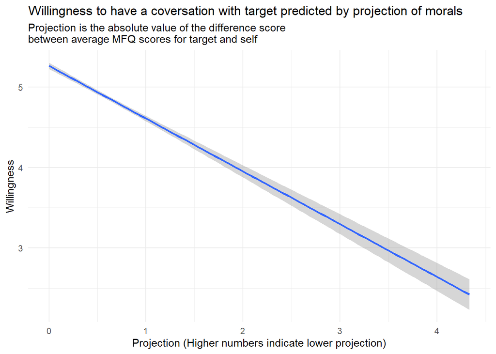

```r
#main effect of projection
ggplot(downstream_analysis, aes(proj_diff, WilltoDiscuss)) +
  geom_smooth(method = "lm") +
  theme_minimal() +
  labs(title = "Willingness to have a coversation with target predicted by projection of morals",
       subtitle = "Projection is the absolute value of the difference score \nbetween average MFQ scores for target and self",
       x = "Projection (Higher numbers indicate lower projection)",
       y = "Willingness")
```

As counter projection increased, willingness to have a conversation with the target decreased.

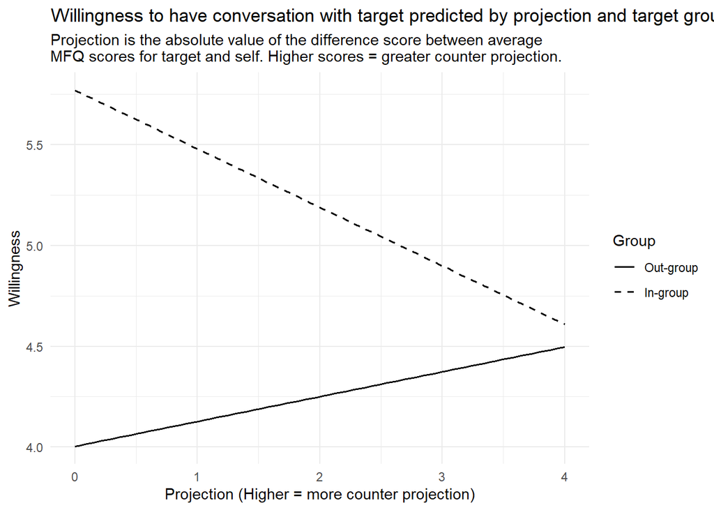

```r
discuss_overall_2way_group <- effect(term = "proj_diff:inoutgroup_effects",
                           xlevels = list(inoutgroup_effects = c(-.5,.5)),
                           mod = discuss_overall)

discuss_overall_2way_group <- as.data.frame(discuss_overall_2way_group)

discuss_overall_2way_group$group <- as.factor(discuss_overall_2way_group$inoutgroup_effects)

ggplot(discuss_overall_2way_group, aes(proj_diff, fit, group = group, color = group)) +
 geom_smooth(method = "lm", se = FALSE, size = .7, colour = "black",
              aes(linetype = group)) +
  theme_minimal() +
  scale_linetype_manual("Group", breaks = c(-.5, .5),
                       labels = c("Out-group", "In-group"),
                       values = c("solid",
                                   "dashed")) +
  labs(title = "Willingness to have conversation with target predicted by projection and target group",
       subtitle = "Projection is the absolute value of the difference score between average \nMFQ scores for target and self. Higher scores = greater counter projection.",
       x = "Projection (Higher = more counter projection)",
       y = "Willingness")
```

Willingness to have a conversation increases for people in the out-group as counter projection increases, while it decreases for the in-group as counter projection occurs. One possible explanation may be that people are willing to have a conversation with their out-group who they see as morally different in order to change them, while people in their in-group who have opposite morals might be more difficult (since they seemingly chose not to have some of the morals the in-group generally seems to share).

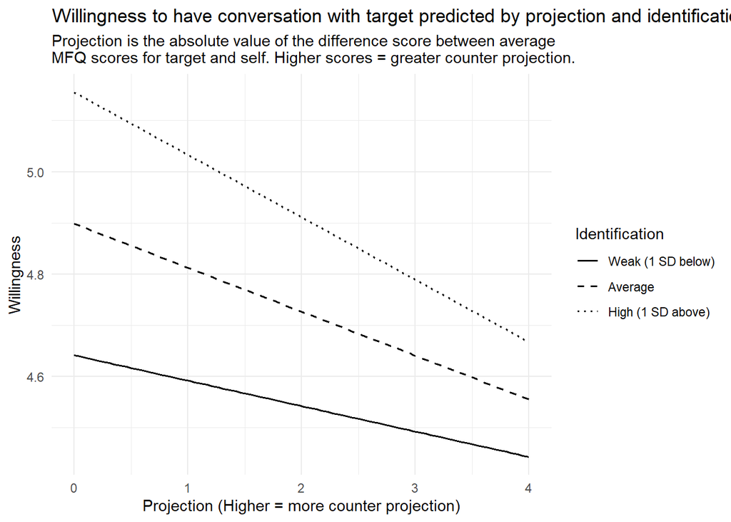

```r
discuss_overall_2way_ident <- effect(term = "proj_diff:ident_c",
                           xlevels = list(ident_c = c(-1.78, 0, 1.78)),
                           mod = discuss_overall)

discuss_overall_2way_ident <- as.data.frame(discuss_overall_2way_ident)

discuss_overall_2way_ident$Identification <- as.factor(discuss_overall_2way_ident$ident_c)

ggplot(discuss_overall_2way_ident, aes(proj_diff, fit, group = Identification, color = Identification)) +
 geom_smooth(method = "lm", se = FALSE, size = .7, colour = "black",
              aes(linetype = Identification)) +
  theme_minimal() +
  scale_linetype_manual("Identification", breaks = c(-1.78, 0, 1.78),
                       labels = c("Weak (1 SD below)",
                                  "Average",
                                  "High (1 SD above)"),
                       values = c("solid",
                                  "dashed",
                                  "dotted")) +
  labs(title = "Willingness to have conversation with target predicted by projection and identification",
       subtitle = "Projection is the absolute value of the difference score between average \nMFQ scores for target and self. Higher scores = greater counter projection.",
       x = "Projection (Higher = more counter projection)",
       y = "Willingness")
```

Willingness to have a conversation starts highest for all levels of identification when they project and this decreases as counter projection increases. However, as can be seen in the plot, the decrease in willingness to discuss as counter projection increases is steepest in higher identifiers, followed by average identifiers.

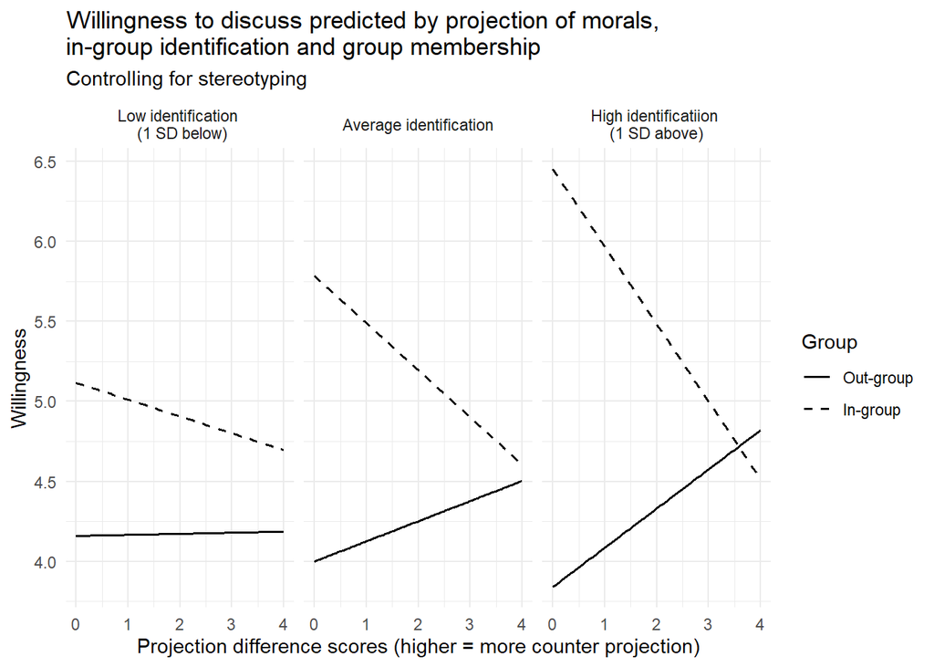

```r
discuss_overall_3way <- effect(term = "proj_diff:inoutgroup_effects:ident_c",
                           xlevels = list(ident_c = c(-1.78, 0, 1.78),
                                         inoutgroup_effects = c(-.5,.5)),
                           mod = discuss_overall)

discuss_overall_3way<- as.data.frame(discuss_overall_3way)

discuss_overall_3way$Group <- as.factor(discuss_overall_3way$inoutgroup_effects)
discuss_overall_3way$Identification <- as.factor(discuss_overall_3way$ident_c)

ident_label <- c("-1.78" = "Low identification \n (1 SD below)",
                 "0" = "Average identification",
                 "1.78" = "High identificatiion \n(1 SD above)")

ggplot(discuss_overall_3way, aes(proj_diff,
                             fit,
                             group = Group,
                             color = Group)) +
  geom_smooth(method = "lm", se = FALSE, size = .7, colour = "black",
              aes(linetype = Group)) +
  facet_wrap(~Identification, labeller =
               labeller(Identification = ident_label)) +
  scale_linetype_manual("Group", breaks = c(-.5, .5),
                       labels = c("Out-group", "In-group"),
                       values = c("solid",
                                   "dashed")) +
  theme_minimal() +
  labs(title = "Willingness to discuss predicted by projection of morals, \nin-group identification and group membership",
       subtitle = "Controlling for stereotyping",
       x = "Projection difference scores (higher = more counter projection)",
       y = "Willingness")
```

Willingness to have a conversation increases the most for out-group targets as counter projection increases and in-group identification increases (weird…). In contrast, willingness to have a conversation with in-group targets decrease as both in-group identification and counter projection increase.

### Binding model output

```r
discuss_bind <- lm(WilltoDiscuss ~ proj_bind_diff*stereo_bind_diff*inoutgroup_effects*ident_c, mfq_binding_diff)
summary(discuss_bind)
```

```
##
## Call:
## lm(formula = WilltoDiscuss ~ proj_bind_diff * stereo_bind_diff *
##     inoutgroup_effects * ident_c, data = mfq_binding_diff)
##
## Residuals:
##     Min      1Q  Median      3Q     Max
## -4.8811 -1.0349  0.2295  1.0608  3.3868
##
## Coefficients:
##                                                             Estimate Std. Error
## (Intercept)                                                 4.992709   0.037290
## proj_bind_diff                                             -0.194038   0.040442
## stereo_bind_diff                                            0.016543   0.042366
## inoutgroup_effects                                          2.121271   0.074579
## ident_c                                                     0.009517   0.022272
## proj_bind_diff:stereo_bind_diff                             0.003772   0.036562
## proj_bind_diff:inoutgroup_effects                          -0.241324   0.080884
## stereo_bind_diff:inoutgroup_effects                        -0.641452   0.084732
## proj_bind_diff:ident_c                                      0.059338   0.019355
## stereo_bind_diff:ident_c                                    0.119775   0.024109
## inoutgroup_effects:ident_c                                  0.027979   0.044543
## proj_bind_diff:stereo_bind_diff:inoutgroup_effects          0.188985   0.073124
## proj_bind_diff:stereo_bind_diff:ident_c                    -0.049685   0.016036
## proj_bind_diff:inoutgroup_effects:ident_c                   0.212977   0.038711
## stereo_bind_diff:inoutgroup_effects:ident_c                 0.310620   0.048219
## proj_bind_diff:stereo_bind_diff:inoutgroup_effects:ident_c -0.150533   0.032072
##                                                            t value
## (Intercept)                                                133.890
## proj_bind_diff                                              -4.798
## stereo_bind_diff                                             0.390
## inoutgroup_effects                                          28.443
## ident_c                                                      0.427
## proj_bind_diff:stereo_bind_diff                              0.103
## proj_bind_diff:inoutgroup_effects                           -2.984
## stereo_bind_diff:inoutgroup_effects                         -7.570
## proj_bind_diff:ident_c                                       3.066
## stereo_bind_diff:ident_c                                     4.968
## inoutgroup_effects:ident_c                                   0.628
## proj_bind_diff:stereo_bind_diff:inoutgroup_effects           2.584
```

[output cut: 29 more lines]

```
## stereo_bind_diff:inoutgroup_effects                        ***
## proj_bind_diff:ident_c                                     **
## stereo_bind_diff:ident_c                                   ***
## inoutgroup_effects:ident_c
## proj_bind_diff:stereo_bind_diff:inoutgroup_effects         **
## proj_bind_diff:stereo_bind_diff:ident_c                    **
## proj_bind_diff:inoutgroup_effects:ident_c                  ***
## stereo_bind_diff:inoutgroup_effects:ident_c                ***
## proj_bind_diff:stereo_bind_diff:inoutgroup_effects:ident_c ***
## ---
## Signif. codes:  0 '***' 0.001 '**' 0.01 '*' 0.05 '.' 0.1 ' ' 1
##
## Residual standard error: 1.685 on 11926 degrees of freedom
## Multiple R-squared:  0.2297, Adjusted R-squared:  0.2287
## F-statistic:   237 on 15 and 11926 DF,  p-value: < 0.00000000000000022
```

### Binding plots

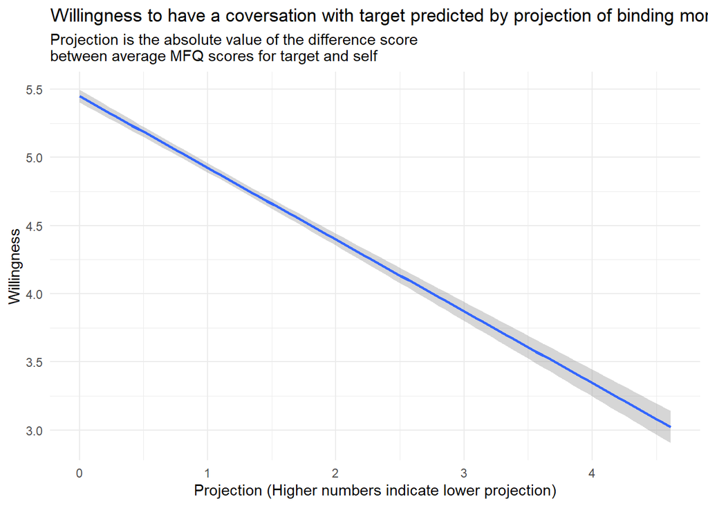

```r
#main effect of projection
ggplot(mfq_binding_diff, aes(proj_bind_diff, WilltoDiscuss)) +
  geom_smooth(method = "lm") +
  theme_minimal() +
  labs(title = "Willingness to have a coversation with target predicted by projection of binding morals",
       subtitle = "Projection is the absolute value of the difference score \nbetween average MFQ scores for target and self",
       x = "Projection (Higher numbers indicate lower projection)",
       y = "Willingness")
```

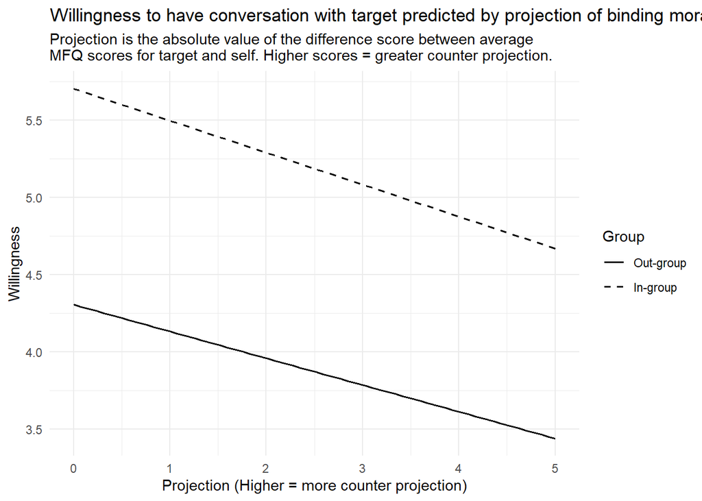

```r
discuss_bind_2way_group <- effect(term = "proj_bind_diff:inoutgroup_effects",
                           xlevels = list(inoutgroup_effects = c(-.5,.5)),
                           mod = discuss_bind)

discuss_bind_2way_group <- as.data.frame(discuss_bind_2way_group)

discuss_bind_2way_group$group <- as.factor(discuss_bind_2way_group$inoutgroup_effects)

ggplot(discuss_bind_2way_group, aes(proj_bind_diff, fit, group = group, color = group)) +
 geom_smooth(method = "lm", se = FALSE, size = .7, colour = "black",
              aes(linetype = group)) +
  theme_minimal() +
  scale_linetype_manual("Group", breaks = c(-.5, .5),
                       labels = c("Out-group", "In-group"),
                       values = c("solid",
                                   "dashed")) +
  labs(title = "Willingness to have conversation with target predicted by projection of binding morals and target group",
       subtitle = "Projection is the absolute value of the difference score between average \nMFQ scores for target and self. Higher scores = greater counter projection.",
       x = "Projection (Higher = more counter projection)",
       y = "Willingness")
```

Doesn’t look like much of an interaction… but, I guess, eventually they would overlap as counter projection increases… Either way, people start out less willing to have a conversation with their out-group than their in-group. As counter projection increases, people’s willingness to discuss decreases for both in and out-group targets, but more quickly for in-group targets.

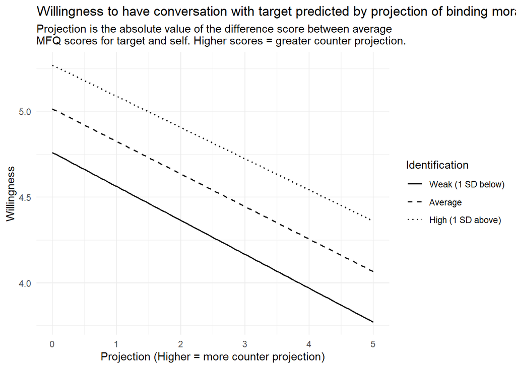

```r
discuss_bind_2way_ident <- effect(term = "proj_bind_diff:ident_c",
                           xlevels = list(ident_c = c(-1.78, 0, 1.78)),
                           mod = discuss_bind)

discuss_bind_2way_ident <- as.data.frame(discuss_bind_2way_ident)

discuss_bind_2way_ident$Identification <- as.factor(discuss_bind_2way_ident$ident_c)

ggplot(discuss_bind_2way_ident, aes(proj_bind_diff, fit, group = Identification, color = Identification)) +
 geom_smooth(method = "lm", se = FALSE, size = .7, colour = "black",
              aes(linetype = Identification)) +
  theme_minimal() +
  scale_linetype_manual("Identification", breaks = c(-1.78, 0, 1.78),
                       labels = c("Weak (1 SD below)",
                                  "Average",
                                  "High (1 SD above)"),
                       values = c("solid",
                                  "dashed",
                                  "dotted")) +
  labs(title = "Willingness to have conversation with target predicted by projection of binding morals and identification",
       subtitle = "Projection is the absolute value of the difference score between average \nMFQ scores for target and self. Higher scores = greater counter projection.",
       x = "Projection (Higher = more counter projection)",
       y = "Willingness")
```

Similar to the last model in not being much of an interaction…

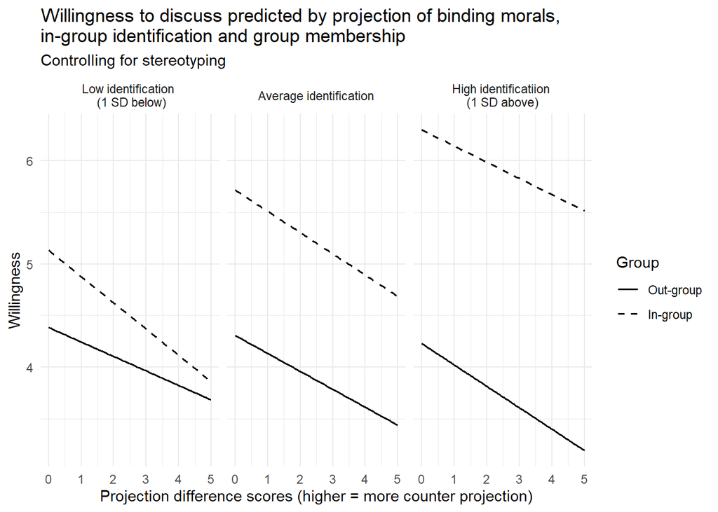

```r
discuss_bind_3way <- effect(term = "proj_bind_diff:inoutgroup_effects:ident_c",
                           xlevels = list(ident_c = c(-1.78, 0, 1.78),
                                         inoutgroup_effects = c(-.5,.5)),
                           mod = discuss_bind)

discuss_bind_3way <- as.data.frame(discuss_bind_3way)

discuss_bind_3way$Group <- as.factor(discuss_bind_3way$inoutgroup_effects)
discuss_bind_3way$Identification <- as.factor(discuss_bind_3way$ident_c)

ident_label <- c("-1.78" = "Low identification \n (1 SD below)",
                 "0" = "Average identification",
                 "1.78" = "High identificatiion \n(1 SD above)")

ggplot(discuss_bind_3way, aes(proj_bind_diff,
                             fit,
                             group = Group,
                             color = Group)) +
  geom_smooth(method = "lm", se = FALSE, size = .7, colour = "black",
              aes(linetype = Group)) +
  facet_wrap(~Identification, labeller =
               labeller(Identification = ident_label)) +
  scale_linetype_manual("Group", breaks = c(-.5, .5),
                       labels = c("Out-group", "In-group"),
                       values = c("solid",
                                   "dashed")) +
  theme_minimal() +
  labs(title = "Willingness to discuss predicted by projection of binding morals, \nin-group identification and group membership",
       subtitle = "Controlling for stereotyping",
       x = "Projection difference scores (higher = more counter projection)",
       y = "Willingness")
```

### Individuating model output

```r
discuss_indiv <- lm(WilltoDiscuss ~ proj_indiv_diff*stereo_indiv_diff*ident_c, mfq_individual_diff)
summary(discuss_indiv)
```

```
##
## Call:
## lm(formula = WilltoDiscuss ~ proj_indiv_diff * stereo_indiv_diff *
##     ident_c, data = mfq_individual_diff)
##
## Residuals:
##     Min      1Q  Median      3Q     Max
## -4.7927 -1.3206  0.3249  1.4753  3.8827
##
## Coefficients: (2 not defined because of singularities)
##                                            Estimate Std. Error t value
## (Intercept)                                5.408883   0.040091 134.915
## proj_indiv_diff                           -0.505269   0.069415  -7.279
## stereo_indiv_diff                                NA         NA      NA
## ident_c                                    0.141374   0.020390   6.934
## proj_indiv_diff:stereo_indiv_diff         -0.033770   0.020897  -1.616
## proj_indiv_diff:ident_c                   -0.024195   0.035072  -0.690
## stereo_indiv_diff:ident_c                        NA         NA      NA
## proj_indiv_diff:stereo_indiv_diff:ident_c -0.002586   0.010005  -0.258
##                                                       Pr(>|t|)
## (Intercept)                               < 0.0000000000000002 ***
## proj_indiv_diff                              0.000000000000369 ***
## stereo_indiv_diff                                           NA
## ident_c                                      0.000000000004424 ***
## proj_indiv_diff:stereo_indiv_diff                        0.106
## proj_indiv_diff:ident_c                                  0.490
## stereo_indiv_diff:ident_c                                   NA
## proj_indiv_diff:stereo_indiv_diff:ident_c                0.796
## ---
## Signif. codes:  0 '***' 0.001 '**' 0.01 '*' 0.05 '.' 0.1 ' ' 1
##
## Residual standard error: 1.828 on 7950 degrees of freedom
## Multiple R-squared:  0.09315,    Adjusted R-squared:  0.09258
## F-statistic: 163.3 on 5 and 7950 DF,  p-value: < 0.00000000000000022
```

## How contentious do you think a conversation about your political views would be with this person?

### Overall model

```r
content_overall <- lm(Contentious ~ proj_diff*stereo_diff*inoutgroup_effects*ident_c, downstream_analysis)
summary(content_overall)
```

```
##
## Call:
## lm(formula = Contentious ~ proj_diff * stereo_diff * inoutgroup_effects *
##     ident_c, data = downstream_analysis)
##
## Residuals:
##    Min     1Q Median     3Q    Max
## -3.930 -1.654  0.204  1.354  4.152
##
## Coefficients:
##                                                  Estimate Std. Error t value
## (Intercept)                                       3.75059    0.03014 124.445
## proj_diff                                         0.32046    0.04986   6.427
## stereo_diff                                       0.43910    0.05074   8.654
## inoutgroup_effects                               -1.80952    0.06028 -30.020
## ident_c                                          -0.02977    0.01622  -1.836
## proj_diff:stereo_diff                            -0.21887    0.06471  -3.382
## proj_diff:inoutgroup_effects                      0.44860    0.09972   4.499
## stereo_diff:inoutgroup_effects                    0.76520    0.10148   7.540
## proj_diff:ident_c                                 0.11142    0.02144   5.197
## stereo_diff:ident_c                               0.18932    0.02601   7.279
## inoutgroup_effects:ident_c                       -0.09929    0.03243  -3.062
## proj_diff:stereo_diff:inoutgroup_effects         -0.45101    0.12942  -3.485
## proj_diff:stereo_diff:ident_c                    -0.13300    0.02106  -6.317
## proj_diff:inoutgroup_effects:ident_c              0.22235    0.04288   5.185
## stereo_diff:inoutgroup_effects:ident_c            0.04862    0.05201   0.935
## proj_diff:stereo_diff:inoutgroup_effects:ident_c -0.08537    0.04211  -2.027
##                                                              Pr(>|t|)
## (Intercept)                                      < 0.0000000000000002 ***
## proj_diff                                          0.0000000001328016 ***
## stereo_diff                                      < 0.0000000000000002 ***
## inoutgroup_effects                               < 0.0000000000000002 ***
## ident_c                                                      0.066426 .
## proj_diff:stereo_diff                                        0.000720 ***
## proj_diff:inoutgroup_effects                       0.0000068773171999 ***
## stereo_diff:inoutgroup_effects                     0.0000000000000489 ***
## proj_diff:ident_c                                  0.0000002049694889 ***
## stereo_diff:ident_c                                0.0000000000003477 ***
## inoutgroup_effects:ident_c                                   0.002204 **
## proj_diff:stereo_diff:inoutgroup_effects                     0.000493 ***
## proj_diff:stereo_diff:ident_c                      0.0000000002729339 ***
## proj_diff:inoutgroup_effects:ident_c               0.0000002177593906 ***
## stereo_diff:inoutgroup_effects:ident_c                       0.349889
## proj_diff:stereo_diff:inoutgroup_effects:ident_c             0.042652 *
## ---
## Signif. codes:  0 '***' 0.001 '**' 0.01 '*' 0.05 '.' 0.1 ' ' 1
##
## Residual standard error: 1.8 on 19882 degrees of freedom
## Multiple R-squared:  0.1572, Adjusted R-squared:  0.1566
## F-statistic: 247.3 on 15 and 19882 DF,  p-value: < 0.00000000000000022
```

### Overall plots

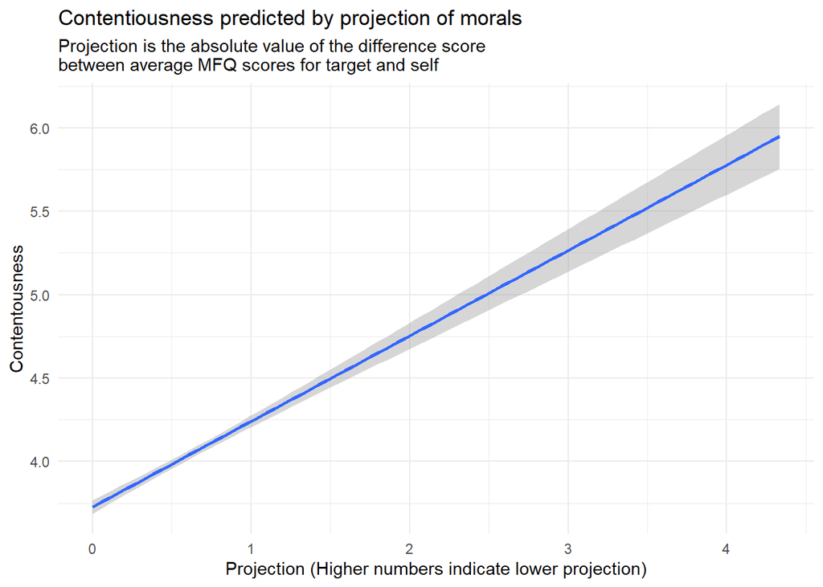

```r
#main effect of projection
ggplot(downstream_analysis, aes(proj_diff, Contentious)) +
  geom_smooth(method = "lm") +
  theme_minimal() +
  labs(title = "Contentiousness predicted by projection of morals",
       subtitle = "Projection is the absolute value of the difference score \nbetween average MFQ scores for target and self",
       x = "Projection (Higher numbers indicate lower projection)",
       y = "Contentousness")
```

As counter projection increases, predicted contentiousness with the target while have a conversation increases.

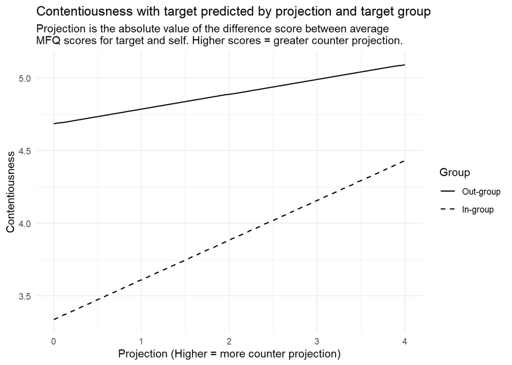

```r
content_overall_2way_group <- effect(term = "proj_diff:inoutgroup_effects",
                           xlevels = list(inoutgroup_effects = c(-.5,.5)),
                           mod = content_overall)

content_overall_2way_group <- as.data.frame(content_overall_2way_group)

content_overall_2way_group$group <- as.factor(content_overall_2way_group$inoutgroup_effects)

ggplot(content_overall_2way_group, aes(proj_diff, fit, group = group, color = group)) +
 geom_smooth(method = "lm", se = FALSE, size = .7, colour = "black",
              aes(linetype = group)) +
  theme_minimal() +
  scale_linetype_manual("Group", breaks = c(-.5, .5),
                       labels = c("Out-group", "In-group"),
                       values = c("solid",
                                   "dashed")) +
  labs(title = "Contentiousness with target predicted by projection and target group",
       subtitle = "Projection is the absolute value of the difference score between average \nMFQ scores for target and self. Higher scores = greater counter projection.",
       x = "Projection (Higher = more counter projection)",
       y = "Contentiousness")
```

Predicted contentiousness with a target starts higher for those considering an out-group target instead of an in-group target and increases gradually as counter projection increases. However, predicted contentiousness increases more quickly as counter projection increases for those considering an in-group target.

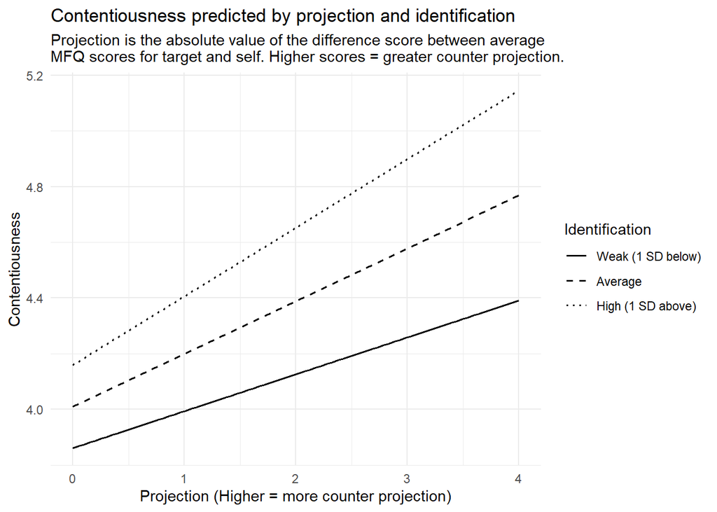

```r
content_overall_2way_ident <- effect(term = "proj_diff:ident_c",
                           xlevels = list(ident_c = c(-1.78, 0, 1.78)),
                           mod = content_overall)

content_overall_2way_ident <- as.data.frame(content_overall_2way_ident)

content_overall_2way_ident$Identification <- as.factor(content_overall_2way_ident$ident_c)

ggplot(content_overall_2way_ident, aes(proj_diff, fit, group = Identification, color = Identification)) +
 geom_smooth(method = "lm", se = FALSE, size = .7, colour = "black",
              aes(linetype = Identification)) +
  theme_minimal() +
  scale_linetype_manual("Identification", breaks = c(-1.78, 0, 1.78),
                       labels = c("Weak (1 SD below)",
                                  "Average",
                                  "High (1 SD above)"),
                       values = c("solid",
                                  "dashed",
                                  "dotted")) +
  labs(title = "Contentiousness predicted by projection and identification",
       subtitle = "Projection is the absolute value of the difference score between average \nMFQ scores for target and self. Higher scores = greater counter projection.",
       x = "Projection (Higher = more counter projection)",
       y = "Contentiousness")
```

Predicted contentiousness starts higher for those who are highly identified with their in-group and increases the most as counter projection increases. On the other hand, contentiousness starts the lowest for those who are weakly identified with their in-group and increases the least as counter projection increases.

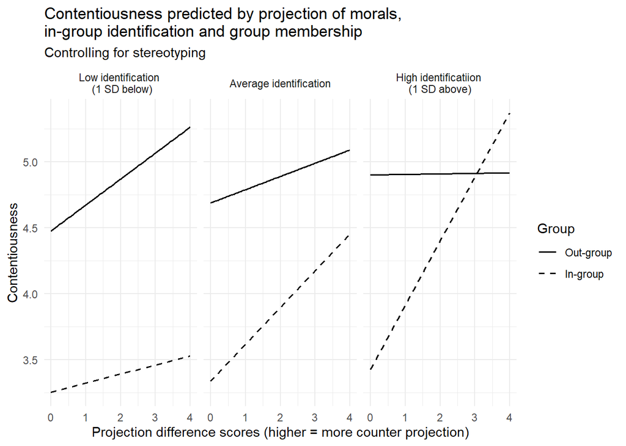

```r
content_overall_3way <- effect(term = "proj_diff:inoutgroup_effects:ident_c",
                           xlevels = list(ident_c = c(-1.78, 0, 1.78),
                                         inoutgroup_effects = c(-.5,.5)),
                           mod = content_overall)

content_overall_3way <- as.data.frame(content_overall_3way)

content_overall_3way$Group <- as.factor(content_overall_3way$inoutgroup_effects)
content_overall_3way$Identification <- as.factor(content_overall_3way$ident_c)

ident_label <- c("-1.78" = "Low identification \n (1 SD below)",
                 "0" = "Average identification",
                 "1.78" = "High identificatiion \n(1 SD above)")

ggplot(content_overall_3way, aes(proj_diff,
                             fit,
                             group = Group,
                             color = Group)) +
  geom_smooth(method = "lm", se = FALSE, size = .7, colour = "black",
              aes(linetype = Group)) +
  facet_wrap(~Identification, labeller =
               labeller(Identification = ident_label)) +
  scale_linetype_manual("Group", breaks = c(-.5, .5),
                       labels = c("Out-group", "In-group"),
                       values = c("solid",
                                   "dashed")) +
  theme_minimal() +
  labs(title = "Contentiousness predicted by projection of morals, \nin-group identification and group membership",
       subtitle = "Controlling for stereotyping",
       x = "Projection difference scores (higher = more counter projection)",
       y = "Contentiousness")
```

For those considering an out-group target, their predicted contentiousness starts higher than those considering an out-group target. As in-group identification increases, counter projection as less of an impact on predicted contentiousness with those considering out-group targets. Specifically, when weakly identified, as counter projection increases, predicted contentiousness also increases. However, when highly identified, predicted contentiousness stays the same as counter projection increases.

For those considering an in-group target, predicted contentiousness increases as counter projection increases, but more so for those who are highly identified with their in-group, followed by average identifiers, with low identifiers only showing a slight increase as counter projection increases. Interestingly, for those who are highly identified, when counter projection is high, people report higher contentiousness with the in-group target than they would with their out-group target.

### Binding model

```r
content_bind <- lm(Contentious ~ proj_bind_diff*stereo_bind_diff*ident_c*inoutgroup_effects, mfq_binding_diff)
summary(content_bind)
```

```
##
## Call:
## lm(formula = Contentious ~ proj_bind_diff * stereo_bind_diff *
##     ident_c * inoutgroup_effects, data = mfq_binding_diff)
##
## Residuals:
##     Min      1Q  Median      3Q     Max
## -4.3664 -1.5604  0.1586  1.4965  4.0397
##
## Coefficients:
##                                                             Estimate Std. Error
## (Intercept)                                                 3.571486   0.039764
## proj_bind_diff                                              0.335843   0.043125
## stereo_bind_diff                                            0.402068   0.045177
## ident_c                                                     0.082495   0.023749
## inoutgroup_effects                                         -1.512059   0.079528
## proj_bind_diff:stereo_bind_diff                            -0.177484   0.038988
## proj_bind_diff:ident_c                                     -0.003608   0.020640
## stereo_bind_diff:ident_c                                    0.036241   0.025709
## proj_bind_diff:inoutgroup_effects                           0.175334   0.086250
## stereo_bind_diff:inoutgroup_effects                         0.707526   0.090354
## ident_c:inoutgroup_effects                                 -0.016837   0.047499
## proj_bind_diff:stereo_bind_diff:ident_c                    -0.008879   0.017100
## proj_bind_diff:stereo_bind_diff:inoutgroup_effects         -0.331031   0.077976
## proj_bind_diff:ident_c:inoutgroup_effects                  -0.017748   0.041280
## stereo_bind_diff:ident_c:inoutgroup_effects                 0.015075   0.051418
## proj_bind_diff:stereo_bind_diff:ident_c:inoutgroup_effects  0.022667   0.034200
##                                                            t value
## (Intercept)                                                 89.817
## proj_bind_diff                                               7.788
## stereo_bind_diff                                             8.900
## ident_c                                                      3.474
## inoutgroup_effects                                         -19.013
## proj_bind_diff:stereo_bind_diff                             -4.552
## proj_bind_diff:ident_c                                      -0.175
## stereo_bind_diff:ident_c                                     1.410
## proj_bind_diff:inoutgroup_effects                            2.033
## stereo_bind_diff:inoutgroup_effects                          7.831
## ident_c:inoutgroup_effects                                  -0.354
## proj_bind_diff:stereo_bind_diff:ident_c                     -0.519
```

[output cut: 29 more lines]

```
## stereo_bind_diff:ident_c
## proj_bind_diff:inoutgroup_effects                          *
## stereo_bind_diff:inoutgroup_effects                        ***
## ident_c:inoutgroup_effects
## proj_bind_diff:stereo_bind_diff:ident_c
## proj_bind_diff:stereo_bind_diff:inoutgroup_effects         ***
## proj_bind_diff:ident_c:inoutgroup_effects
## stereo_bind_diff:ident_c:inoutgroup_effects
## proj_bind_diff:stereo_bind_diff:ident_c:inoutgroup_effects
## ---
## Signif. codes:  0 '***' 0.001 '**' 0.01 '*' 0.05 '.' 0.1 ' ' 1
##
## Residual standard error: 1.797 on 11926 degrees of freedom
## Multiple R-squared:  0.1601, Adjusted R-squared:  0.159
## F-statistic: 151.5 on 15 and 11926 DF,  p-value: < 0.00000000000000022
```

### Binding plots

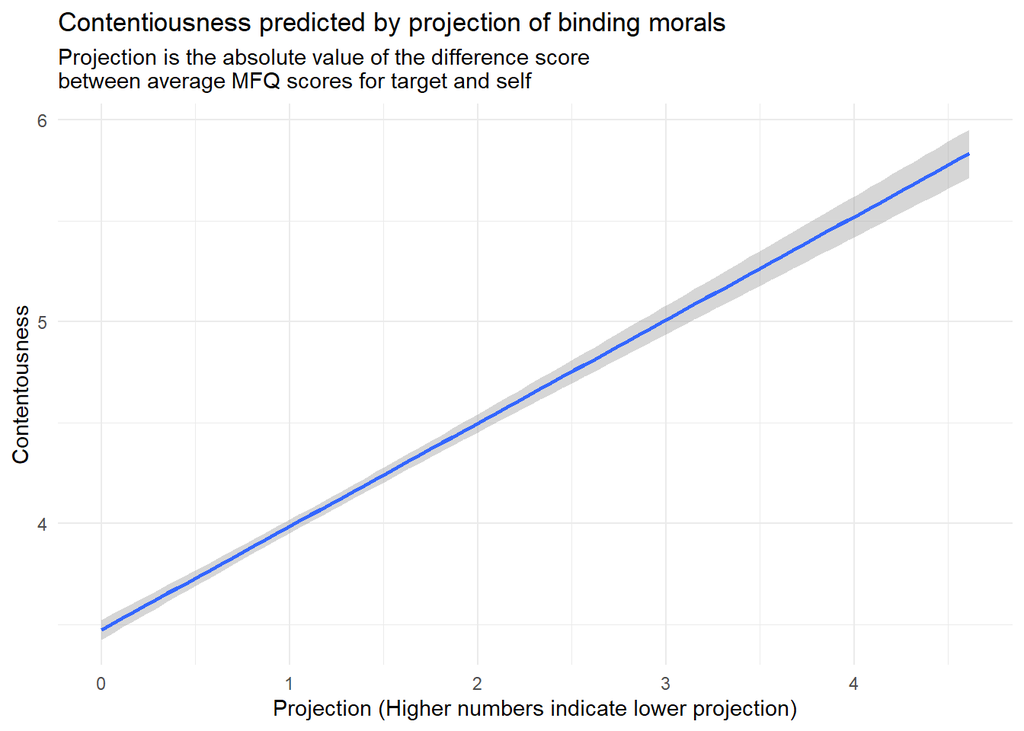

```r
ggplot(mfq_binding_diff, aes(proj_bind_diff, Contentious)) +
  geom_smooth(method = "lm") +
  theme_minimal() +
  labs(title = "Contentiousness predicted by projection of binding morals",
       subtitle = "Projection is the absolute value of the difference score \nbetween average MFQ scores for target and self",
       x = "Projection (Higher numbers indicate lower projection)",
       y = "Contentousness")
```

As counter projection increases, predicted contentiousness with the target while have a conversation increases.

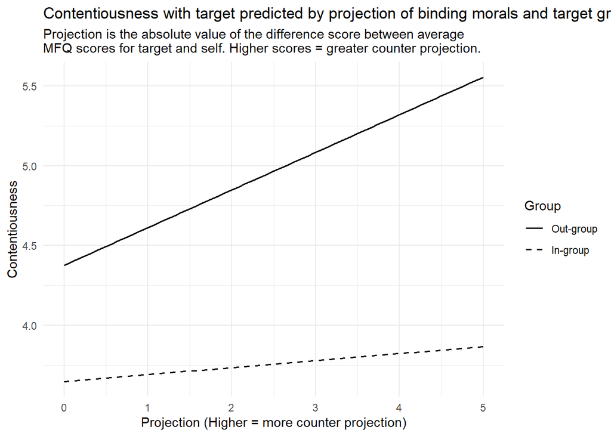

```r
content_bind_2way_group <- effect(term = "proj_bind_diff:inoutgroup_effects",
                           xlevels = list(inoutgroup_effects = c(-.5,.5)),
                           mod = content_bind)

content_bind_2way_group <- as.data.frame(content_bind_2way_group)

content_bind_2way_group$group <- as.factor(content_bind_2way_group$inoutgroup_effects)

ggplot(content_bind_2way_group, aes(proj_bind_diff, fit, group = group, color = group)) +
 geom_smooth(method = "lm", se = FALSE, size = .7, colour = "black",
              aes(linetype = group)) +
  theme_minimal() +
  scale_linetype_manual("Group", breaks = c(-.5, .5),
                       labels = c("Out-group", "In-group"),
                       values = c("solid",
                                   "dashed")) +
  labs(title = "Contentiousness with target predicted by projection of binding morals and target group",
       subtitle = "Projection is the absolute value of the difference score between average \nMFQ scores for target and self. Higher scores = greater counter projection.",
       x = "Projection (Higher = more counter projection)",
       y = "Contentiousness")
```

Predicted contentiousness was higher for out-group targets than in-group targets and, as counter projection of binding morals increases, contentiousness increases more for out-group targets as well.

### Individuating model

```r
content_indiv <- lm(Contentious  ~ proj_indiv_diff*stereo_indiv_diff*ident_c*inoutgroup_effects, mfq_individual_diff)
summary(content_indiv)
```

```
##
## Call:
## lm(formula = Contentious ~ proj_indiv_diff * stereo_indiv_diff *
##     ident_c * inoutgroup_effects, data = mfq_individual_diff)
##
## Residuals:
##     Min      1Q  Median      3Q     Max
## -4.6935 -1.5171  0.1004  1.5046  4.0585
##
## Coefficients: (4 not defined because of singularities)
##                                                               Estimate
## (Intercept)                                                   3.748895
## proj_indiv_diff                                               0.587006
## stereo_indiv_diff                                                   NA
## ident_c                                                       0.059289
## inoutgroup_effects                                           -1.484698
## proj_indiv_diff:stereo_indiv_diff                            -0.286512
## proj_indiv_diff:ident_c                                       0.132058
## stereo_indiv_diff:ident_c                                           NA
## proj_indiv_diff:inoutgroup_effects                            1.019028
## stereo_indiv_diff:inoutgroup_effects                                NA
## ident_c:inoutgroup_effects                                    0.001465
## proj_indiv_diff:stereo_indiv_diff:ident_c                    -0.107484
## proj_indiv_diff:stereo_indiv_diff:inoutgroup_effects         -0.697440
## proj_indiv_diff:ident_c:inoutgroup_effects                    0.029069
## stereo_indiv_diff:ident_c:inoutgroup_effects                        NA
## proj_indiv_diff:stereo_indiv_diff:ident_c:inoutgroup_effects -0.100359
##                                                              Std. Error t value
## (Intercept)                                                    0.044931  83.437
## proj_indiv_diff                                                0.101837   5.764
## stereo_indiv_diff                                                    NA      NA
## ident_c                                                        0.022265   2.663
## inoutgroup_effects                                             0.089862 -16.522
## proj_indiv_diff:stereo_indiv_diff                              0.054685  -5.239
## proj_indiv_diff:ident_c                                        0.051226   2.578
## stereo_indiv_diff:ident_c                                            NA      NA
## proj_indiv_diff:inoutgroup_effects                             0.203674   5.003
## stereo_indiv_diff:inoutgroup_effects                                 NA      NA
## ident_c:inoutgroup_effects                                     0.044529   0.033
## proj_indiv_diff:stereo_indiv_diff:ident_c                      0.025678  -4.186
```

[output cut: 29 more lines]

```
## stereo_indiv_diff:ident_c
## proj_indiv_diff:inoutgroup_effects                           ***
## stereo_indiv_diff:inoutgroup_effects
## ident_c:inoutgroup_effects
## proj_indiv_diff:stereo_indiv_diff:ident_c                    ***
## proj_indiv_diff:stereo_indiv_diff:inoutgroup_effects         ***
## proj_indiv_diff:ident_c:inoutgroup_effects
## stereo_indiv_diff:ident_c:inoutgroup_effects
## proj_indiv_diff:stereo_indiv_diff:ident_c:inoutgroup_effects .
## ---
## Signif. codes:  0 '***' 0.001 '**' 0.01 '*' 0.05 '.' 0.1 ' ' 1
##
## Residual standard error: 1.799 on 7944 degrees of freedom
## Multiple R-squared:  0.1593, Adjusted R-squared:  0.1582
## F-statistic: 136.9 on 11 and 7944 DF,  p-value: < 0.00000000000000022
```

## How well you think the target would treat you during this conversation?

### Overall model

```r
treat_overall <- lm(Treatment ~ proj_diff*stereo_diff*inoutgroup_effects*ident_c, downstream_analysis)
summary(treat_overall)
```

```
##
## Call:
## lm(formula = Treatment ~ proj_diff * stereo_diff * inoutgroup_effects *
##     ident_c, data = downstream_analysis)
##
## Residuals:
##     Min      1Q  Median      3Q     Max
## -4.6108 -0.8958  0.1467  0.8811  3.9993
##
## Coefficients:
##                                                  Estimate Std. Error t value
## (Intercept)                                       5.03368    0.02348 214.380
## proj_diff                                        -0.03487    0.03884  -0.898
## stereo_diff                                      -0.12835    0.03953  -3.247
## inoutgroup_effects                                2.06058    0.04696  43.879
## ident_c                                           0.06298    0.01263   4.985
## proj_diff:stereo_diff                            -0.18435    0.05041  -3.657
## proj_diff:inoutgroup_effects                      0.49875    0.07769   6.420
## stereo_diff:inoutgroup_effects                    0.50920    0.07906   6.441
## proj_diff:ident_c                                -0.10189    0.01670  -6.100
## stereo_diff:ident_c                               0.05234    0.02026   2.583
## inoutgroup_effects:ident_c                        0.29728    0.02527  11.766
## proj_diff:stereo_diff:inoutgroup_effects         -0.52275    0.10083  -5.185
## proj_diff:stereo_diff:ident_c                     0.01939    0.01640   1.182
## proj_diff:inoutgroup_effects:ident_c             -0.04374    0.03341  -1.309
## stereo_diff:inoutgroup_effects:ident_c           -0.08137    0.04052  -2.008
## proj_diff:stereo_diff:inoutgroup_effects:ident_c  0.05451    0.03281   1.662
##                                                              Pr(>|t|)
## (Intercept)                                      < 0.0000000000000002 ***
## proj_diff                                                    0.369299
## stereo_diff                                                  0.001169 **
## inoutgroup_effects                               < 0.0000000000000002 ***
## ident_c                                                0.000000624328 ***
## proj_diff:stereo_diff                                        0.000256 ***
## proj_diff:inoutgroup_effects                           0.000000000139 ***
## stereo_diff:inoutgroup_effects                         0.000000000122 ***
## proj_diff:ident_c                                      0.000000001083 ***
## stereo_diff:ident_c                                          0.009798 **
## inoutgroup_effects:ident_c                       < 0.0000000000000002 ***
## proj_diff:stereo_diff:inoutgroup_effects               0.000000218685 ***
## proj_diff:stereo_diff:ident_c                                0.237322
## proj_diff:inoutgroup_effects:ident_c                         0.190411
## stereo_diff:inoutgroup_effects:ident_c                       0.044643 *
## proj_diff:stereo_diff:inoutgroup_effects:ident_c             0.096613 .
## ---
## Signif. codes:  0 '***' 0.001 '**' 0.01 '*' 0.05 '.' 0.1 ' ' 1
##
## Residual standard error: 1.402 on 19882 degrees of freedom
## Multiple R-squared:  0.4673, Adjusted R-squared:  0.4669
## F-statistic:  1163 on 15 and 19882 DF,  p-value: < 0.00000000000000022
```

No main effect for treatment - the only outcome in which this occurs.

### Overall plots

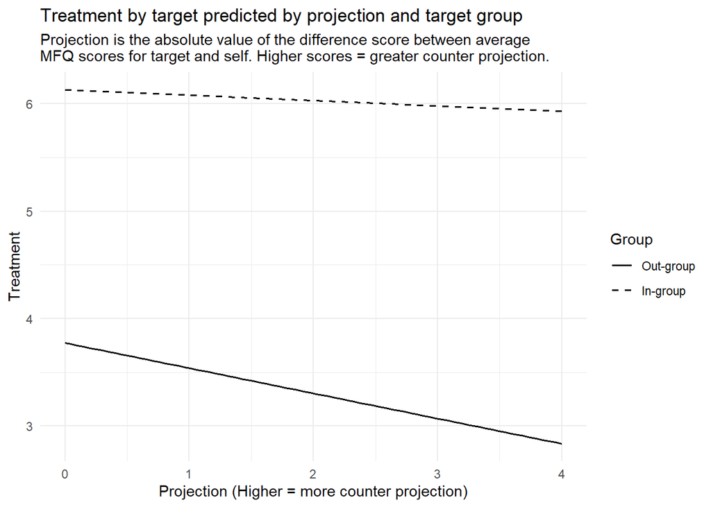

```r
treat_overall_2way_group <- effect(term = "proj_diff:inoutgroup_effects",
                           xlevels = list(inoutgroup_effects = c(-.5,.5)),
                           mod = treat_overall)

treat_overall_2way_group <- as.data.frame(treat_overall_2way_group)

treat_overall_2way_group$group <- as.factor(treat_overall_2way_group$inoutgroup_effects)

ggplot(treat_overall_2way_group, aes(proj_diff, fit, group = group, color = group)) +
 geom_smooth(method = "lm", se = FALSE, size = .7, colour = "black",
              aes(linetype = group)) +
  theme_minimal() +
  scale_linetype_manual("Group", breaks = c(-.5, .5),
                       labels = c("Out-group", "In-group"),
                       values = c("solid",
                                   "dashed")) +
  labs(title = "Treatment by target predicted by projection and target group",
       subtitle = "Projection is the absolute value of the difference score between average \nMFQ scores for target and self. Higher scores = greater counter projection.",
       x = "Projection (Higher = more counter projection)",
       y = "Treatment")
```

Participants expected the target to treat them better in the in-group than the out-group. As counter projection increased, expected treatment decreased for the out-group, while only barely decreasing for the in-group.

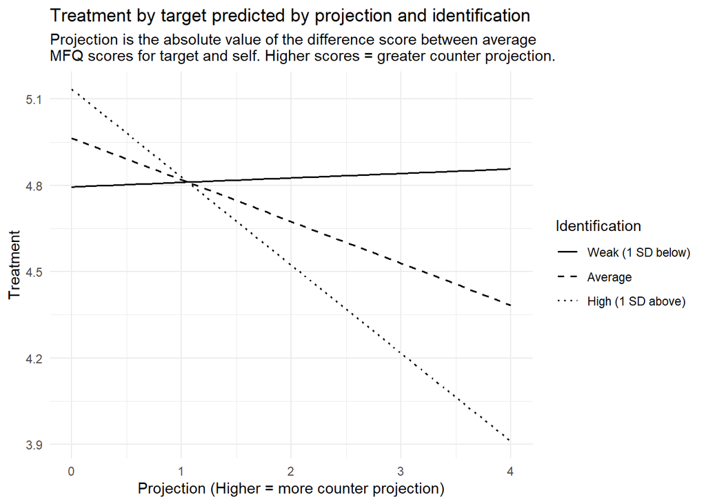

```r
treat_overall_2way_ident <- effect(term = "proj_diff:ident_c",
                           xlevels = list(ident_c = c(-1.78, 0, 1.78)),
                           mod = treat_overall)

treat_overall_2way_ident <- as.data.frame(treat_overall_2way_ident)

treat_overall_2way_ident$Identification <- as.factor(treat_overall_2way_ident$ident_c)

ggplot(treat_overall_2way_ident, aes(proj_diff, fit, group = Identification, color = Identification)) +
 geom_smooth(method = "lm", se = FALSE, size = .7, colour = "black",
              aes(linetype = Identification)) +
  theme_minimal() +
  scale_linetype_manual("Identification", breaks = c(-1.78, 0, 1.78),
                       labels = c("Weak (1 SD below)",
                                  "Average",
                                  "High (1 SD above)"),
                       values = c("solid",
                                  "dashed",
                                  "dotted")) +
  labs(title = "Treatment by target predicted by projection and identification",
       subtitle = "Projection is the absolute value of the difference score between average \nMFQ scores for target and self. Higher scores = greater counter projection.",
       x = "Projection (Higher = more counter projection)",
       y = "Treatment")
```

For people who weakly identify with their in-group, as counter projection increases, expected treatment slightly increases. However, for people who identify with their in-group an average amount or highly, as counter projection increases, expected treatment decreases, with it decreasing the most for people who highly identified with their in-group.

### Binding model

```r
treat_bind <- lm(Treatment ~ proj_bind_diff*stereo_bind_diff*inoutgroup_effects*ident_c, mfq_binding_diff)
summary(treat_bind)
```

```
##
## Call:
## lm(formula = Treatment ~ proj_bind_diff * stereo_bind_diff *
##     inoutgroup_effects * ident_c, data = mfq_binding_diff)
##
## Residuals:
##     Min      1Q  Median      3Q     Max
## -4.0579 -0.9026  0.0396  0.8792  4.1841
##
## Coefficients:
##                                                             Estimate Std. Error
## (Intercept)                                                 5.166238   0.030315
## proj_bind_diff                                             -0.052612   0.032878
## stereo_bind_diff                                           -0.102178   0.034442
## inoutgroup_effects                                          2.037037   0.060630
## ident_c                                                     0.034729   0.018106
## proj_bind_diff:stereo_bind_diff                            -0.028398   0.029724
## proj_bind_diff:inoutgroup_effects                           0.098765   0.065755
## stereo_bind_diff:inoutgroup_effects                         0.001159   0.068884
## proj_bind_diff:ident_c                                     -0.023310   0.015735
## stereo_bind_diff:ident_c                                   -0.008528   0.019600
## inoutgroup_effects:ident_c                                  0.176580   0.036212
## proj_bind_diff:stereo_bind_diff:inoutgroup_effects          0.077894   0.059447
## proj_bind_diff:stereo_bind_diff:ident_c                     0.032445   0.013037
## proj_bind_diff:inoutgroup_effects:ident_c                   0.187069   0.031471
## stereo_bind_diff:inoutgroup_effects:ident_c                -0.050736   0.039200
## proj_bind_diff:stereo_bind_diff:inoutgroup_effects:ident_c  0.002489   0.026073
##                                                            t value
## (Intercept)                                                170.419
## proj_bind_diff                                              -1.600
## stereo_bind_diff                                            -2.967
## inoutgroup_effects                                          33.598
## ident_c                                                      1.918
## proj_bind_diff:stereo_bind_diff                             -0.955
## proj_bind_diff:inoutgroup_effects                            1.502
## stereo_bind_diff:inoutgroup_effects                          0.017
## proj_bind_diff:ident_c                                      -1.481
## stereo_bind_diff:ident_c                                    -0.435
## inoutgroup_effects:ident_c                                   4.876
## proj_bind_diff:stereo_bind_diff:inoutgroup_effects           1.310
```

[output cut: 29 more lines]

```
## stereo_bind_diff:inoutgroup_effects
## proj_bind_diff:ident_c
## stereo_bind_diff:ident_c
## inoutgroup_effects:ident_c                                 ***
## proj_bind_diff:stereo_bind_diff:inoutgroup_effects
## proj_bind_diff:stereo_bind_diff:ident_c                    *
## proj_bind_diff:inoutgroup_effects:ident_c                  ***
## stereo_bind_diff:inoutgroup_effects:ident_c
## proj_bind_diff:stereo_bind_diff:inoutgroup_effects:ident_c
## ---
## Signif. codes:  0 '***' 0.001 '**' 0.01 '*' 0.05 '.' 0.1 ' ' 1
##
## Residual standard error: 1.37 on 11926 degrees of freedom
## Multiple R-squared:  0.4915, Adjusted R-squared:  0.4909
## F-statistic: 768.6 on 15 and 11926 DF,  p-value: < 0.00000000000000022
```

### Binding plots

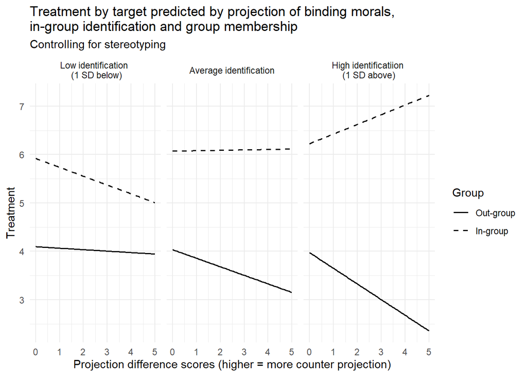

```r
treat_bind_3way <- effect(term = "proj_bind_diff:inoutgroup_effects:ident_c",
                           xlevels = list(ident_c = c(-1.78, 0, 1.78),
                                         inoutgroup_effects = c(-.5,.5)),
                           mod = treat_bind)

treat_bind_3way <- as.data.frame(treat_bind_3way)

treat_bind_3way$Group <- as.factor(treat_bind_3way$inoutgroup_effects)
treat_bind_3way$Identification <- as.factor(treat_bind_3way$ident_c)

ident_label <- c("-1.78" = "Low identification \n (1 SD below)",
                 "0" = "Average identification",
                 "1.78" = "High identificatiion \n(1 SD above)")

ggplot(treat_bind_3way, aes(proj_bind_diff,
                             fit,
                             group = Group,
                             color = Group)) +
  geom_smooth(method = "lm", se = FALSE, size = .7, colour = "black",
              aes(linetype = Group)) +
  facet_wrap(~Identification, labeller =
               labeller(Identification = ident_label)) +
  scale_linetype_manual("Group", breaks = c(-.5, .5),
                       labels = c("Out-group", "In-group"),
                       values = c("solid",
                                   "dashed")) +
  theme_minimal() +
  labs(title = "Treatment by target predicted by projection of binding morals, \nin-group identification and group membership",
       subtitle = "Controlling for stereotyping",
       x = "Projection difference scores (higher = more counter projection)",
       y = "Treatment")
```

All treatment scores for the in-group condition were higher than those in the out-group. People in the low identification condition expected their in-group to treat them better than their out-group; However, as counter projection increased, expected treatment decreased for those in the in-group condition, while remaining the same for those in the out-group condition. For those who reported average in-group identification, as counter projection increased, people in the out-group condition reported worse treatment scores, while those in the in-group did not report a change. For those who reported high in-group identification, as count projection increased, people expected their out-group to treat them worse, while people expected their in-group to treat them better.

### Individuating model

```r
treat_indiv <- lm(Treatment  ~ proj_indiv_diff*stereo_indiv_diff*inoutgroup_effects*ident_c, mfq_individual_diff)
summary(treat_indiv)
```

```
##
## Call:
## lm(formula = Treatment ~ proj_indiv_diff * stereo_indiv_diff *
##     inoutgroup_effects * ident_c, data = mfq_individual_diff)
##
## Residuals:
##     Min      1Q  Median      3Q     Max
## -4.3671 -0.8971  0.0353  0.8282  4.7280
##
## Coefficients: (4 not defined because of singularities)
##                                                               Estimate
## (Intercept)                                                   5.219881
## proj_indiv_diff                                              -0.205322
## stereo_indiv_diff                                                   NA
## inoutgroup_effects                                            1.739202
## ident_c                                                      -0.004403
## proj_indiv_diff:stereo_indiv_diff                            -0.068976
## proj_indiv_diff:inoutgroup_effects                            0.795450
## stereo_indiv_diff:inoutgroup_effects                                NA
## proj_indiv_diff:ident_c                                       0.038730
## stereo_indiv_diff:ident_c                                           NA
## inoutgroup_effects:ident_c                                    0.262681
## proj_indiv_diff:stereo_indiv_diff:inoutgroup_effects         -0.143315
## proj_indiv_diff:stereo_indiv_diff:ident_c                     0.026045
## proj_indiv_diff:inoutgroup_effects:ident_c                    0.020209
## stereo_indiv_diff:inoutgroup_effects:ident_c                        NA
## proj_indiv_diff:stereo_indiv_diff:inoutgroup_effects:ident_c  0.037263
##                                                              Std. Error t value
## (Intercept)                                                    0.033704 154.873
## proj_indiv_diff                                                0.076391  -2.688
## stereo_indiv_diff                                                    NA      NA
## inoutgroup_effects                                             0.067409  25.801
## ident_c                                                        0.016701  -0.264
## proj_indiv_diff:stereo_indiv_diff                              0.041021  -1.682
## proj_indiv_diff:inoutgroup_effects                             0.152783   5.206
## stereo_indiv_diff:inoutgroup_effects                                 NA      NA
## proj_indiv_diff:ident_c                                        0.038426   1.008
## stereo_indiv_diff:ident_c                                            NA      NA
## inoutgroup_effects:ident_c                                     0.033403   7.864
## proj_indiv_diff:stereo_indiv_diff:inoutgroup_effects           0.082041  -1.747
```

[output cut: 29 more lines]

```
## stereo_indiv_diff:inoutgroup_effects
## proj_indiv_diff:ident_c
## stereo_indiv_diff:ident_c
## inoutgroup_effects:ident_c                                   ***
## proj_indiv_diff:stereo_indiv_diff:inoutgroup_effects         .
## proj_indiv_diff:stereo_indiv_diff:ident_c
## proj_indiv_diff:inoutgroup_effects:ident_c
## stereo_indiv_diff:inoutgroup_effects:ident_c
## proj_indiv_diff:stereo_indiv_diff:inoutgroup_effects:ident_c
## ---
## Signif. codes:  0 '***' 0.001 '**' 0.01 '*' 0.05 '.' 0.1 ' ' 1
##
## Residual standard error: 1.35 on 7944 degrees of freedom
## Multiple R-squared:  0.5074, Adjusted R-squared:  0.5067
## F-statistic: 743.8 on 11 and 7944 DF,  p-value: < 0.00000000000000022
```

## How valid do you think the target’s political position is?

### Overall model

```r
valid_overall <- lm(Valid ~ proj_diff*stereo_diff*inoutgroup_effects*ident_c, downstream_analysis)
summary(valid_overall)
```

```
##
## Call:
## lm(formula = Valid ~ proj_diff * stereo_diff * inoutgroup_effects *
##     ident_c, data = downstream_analysis)
##
## Residuals:
##     Min      1Q  Median      3Q     Max
## -4.5140 -0.8753  0.2023  0.8358  4.0343
##
## Coefficients:
##                                                   Estimate Std. Error t value
## (Intercept)                                       5.065294   0.024030 210.791
## proj_diff                                        -0.109852   0.039753  -2.763
## stereo_diff                                      -0.262408   0.040456  -6.486
## inoutgroup_effects                                2.345308   0.048060  48.800
## ident_c                                           0.157067   0.012929  12.148
## proj_diff:stereo_diff                             0.018244   0.051594   0.354
## proj_diff:inoutgroup_effects                      0.253932   0.079506   3.194
## stereo_diff:inoutgroup_effects                    0.216820   0.080911   2.680
## proj_diff:ident_c                                -0.063391   0.017095  -3.708
## stereo_diff:ident_c                              -0.024831   0.020736  -1.197
## inoutgroup_effects:ident_c                       -0.071014   0.025858  -2.746
## proj_diff:stereo_diff:inoutgroup_effects         -0.195846   0.103189  -1.898
## proj_diff:stereo_diff:ident_c                     0.005674   0.016788   0.338
## proj_diff:inoutgroup_effects:ident_c              0.136726   0.034190   3.999
## stereo_diff:inoutgroup_effects:ident_c            0.203792   0.041472   4.914
## proj_diff:stereo_diff:inoutgroup_effects:ident_c -0.027411   0.033576  -0.816
##                                                              Pr(>|t|)
## (Intercept)                                      < 0.0000000000000002 ***
## proj_diff                                                    0.005727 **
## stereo_diff                                             0.00000000009 ***
## inoutgroup_effects                               < 0.0000000000000002 ***
## ident_c                                          < 0.0000000000000002 ***
## proj_diff:stereo_diff                                        0.723638
## proj_diff:inoutgroup_effects                                 0.001406 **
## stereo_diff:inoutgroup_effects                               0.007374 **
## proj_diff:ident_c                                            0.000209 ***
## stereo_diff:ident_c                                          0.231136
## inoutgroup_effects:ident_c                                   0.006033 **
## proj_diff:stereo_diff:inoutgroup_effects                     0.057719 .
## proj_diff:stereo_diff:ident_c                                0.735376
## proj_diff:inoutgroup_effects:ident_c                    0.00006384085 ***
## stereo_diff:inoutgroup_effects:ident_c                  0.00000089938 ***
## proj_diff:stereo_diff:inoutgroup_effects:ident_c             0.414284
## ---
## Signif. codes:  0 '***' 0.001 '**' 0.01 '*' 0.05 '.' 0.1 ' ' 1
##
## Residual standard error: 1.435 on 19882 degrees of freedom
## Multiple R-squared:  0.4734, Adjusted R-squared:  0.473
## F-statistic:  1191 on 15 and 19882 DF,  p-value: < 0.00000000000000022
```

### Overall plots

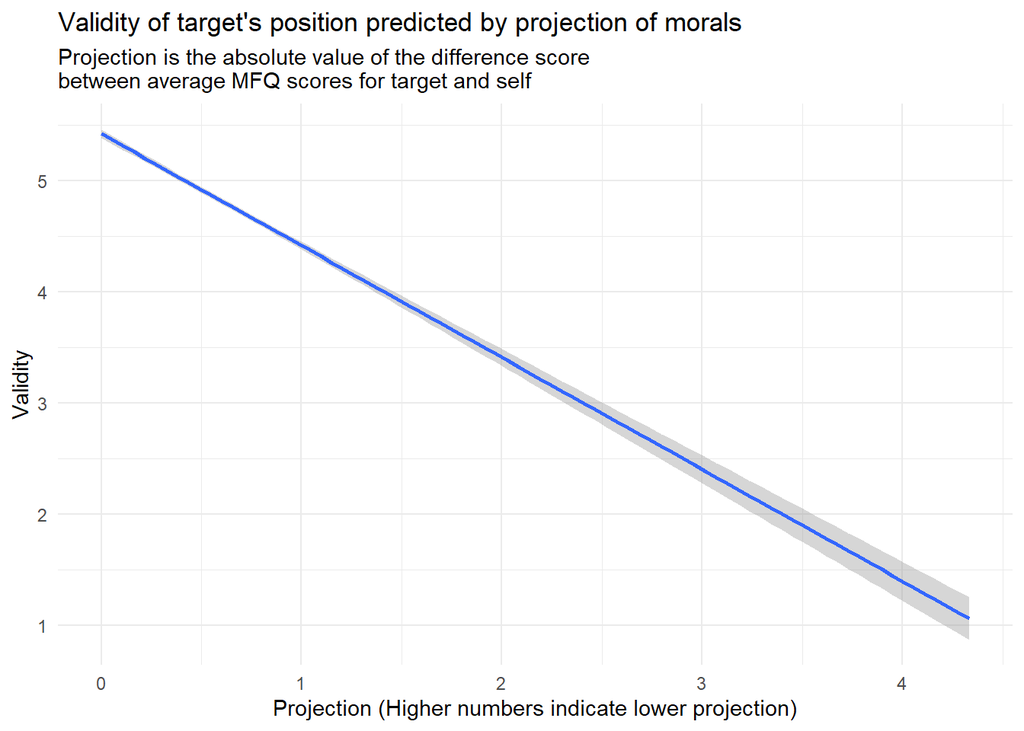

```r
ggplot(downstream_analysis, aes(proj_diff, Valid)) +
  geom_smooth(method = "lm") +
  theme_minimal() +
  labs(title = "Validity of target's position predicted by projection of morals",
       subtitle = "Projection is the absolute value of the difference score \nbetween average MFQ scores for target and self",
       x = "Projection (Higher numbers indicate lower projection)",
       y = "Validity")
```

As counter projection increases, validity of the target’s position decreases.

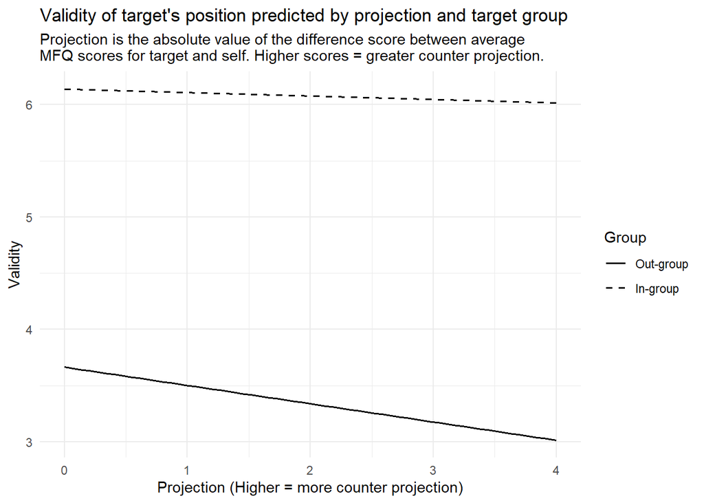

```r
valid_overall_2way_group <- effect(term = "proj_diff:inoutgroup_effects",
                           xlevels = list(inoutgroup_effects = c(-.5,.5)),
                           mod = valid_overall)

valid_overall_2way_group <- as.data.frame(valid_overall_2way_group)

valid_overall_2way_group$group <- as.factor(valid_overall_2way_group$inoutgroup_effects)

ggplot(valid_overall_2way_group, aes(proj_diff, fit, group = group, color = group)) +
 geom_smooth(method = "lm", se = FALSE, size = .7, colour = "black",
              aes(linetype = group)) +
  theme_minimal() +
  scale_linetype_manual("Group", breaks = c(-.5, .5),
                       labels = c("Out-group", "In-group"),
                       values = c("solid",
                                   "dashed")) +
  labs(title = "Validity of target's position predicted by projection and target group",
       subtitle = "Projection is the absolute value of the difference score between average \nMFQ scores for target and self. Higher scores = greater counter projection.",
       x = "Projection (Higher = more counter projection)",
       y = "Validity")
```

People report higher validity of target’s position in the in-group condition than out-group condition and, as counter projection increases, validity decreases more in the out-group condition than the in-group condition.

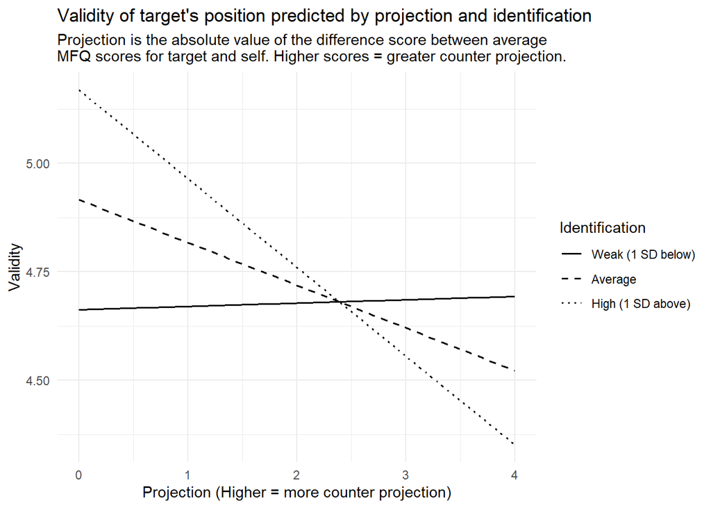

```r
valid_overall_2way_ident <- effect(term = "proj_diff:ident_c",
                           xlevels = list(ident_c = c(-1.78, 0, 1.78)),
                           mod = valid_overall)

valid_overall_2way_ident <- as.data.frame(valid_overall_2way_ident)

valid_overall_2way_ident$Identification <- as.factor(valid_overall_2way_ident$ident_c)

ggplot(valid_overall_2way_ident, aes(proj_diff, fit, group = Identification, color = Identification)) +
 geom_smooth(method = "lm", se = FALSE, size = .7, colour = "black",
              aes(linetype = Identification)) +
  theme_minimal() +
  scale_linetype_manual("Identification", breaks = c(-1.78, 0, 1.78),
                       labels = c("Weak (1 SD below)",
                                  "Average",
                                  "High (1 SD above)"),
                       values = c("solid",
                                  "dashed",
                                  "dotted")) +
  labs(title = "Validity of target's position predicted by projection and identification",
       subtitle = "Projection is the absolute value of the difference score between average \nMFQ scores for target and self. Higher scores = greater counter projection.",
       x = "Projection (Higher = more counter projection)",
       y = "Validity")
```

As counter projection increases, those who report highly identifying with their in-group report the largest decrease in validity of the target’s opinion, followed by those who identify with their in-group an average amount. Those who weakly identify with their in-group actually show a slight increase in reported validity as counter projection increases.

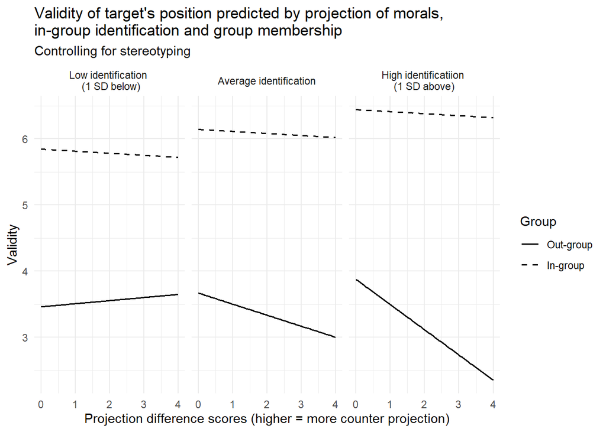

```r
valid_overall_3way <- effect(term = "proj_diff:inoutgroup_effects:ident_c",
                           xlevels = list(ident_c = c(-1.78, 0, 1.78),
                                         inoutgroup_effects = c(-.5,.5)),
                           mod = valid_overall)

valid_overall_3way <- as.data.frame(valid_overall_3way)

valid_overall_3way$Group <- as.factor(valid_overall_3way$inoutgroup_effects)
valid_overall_3way$Identification <- as.factor(valid_overall_3way$ident_c)

ident_label <- c("-1.78" = "Low identification \n (1 SD below)",
                 "0" = "Average identification",
                 "1.78" = "High identificatiion \n(1 SD above)")

ggplot(valid_overall_3way, aes(proj_diff,
                             fit,
                             group = Group,
                             color = Group)) +
  geom_smooth(method = "lm", se = FALSE, size = .7, colour = "black",
              aes(linetype = Group)) +
  facet_wrap(~Identification, labeller =
               labeller(Identification = ident_label)) +
  scale_linetype_manual("Group", breaks = c(-.5, .5),
                       labels = c("Out-group", "In-group"),
                       values = c("solid",
                                   "dashed")) +
  theme_minimal() +
  labs(title = "Validity of target's position predicted by projection of morals, \nin-group identification and group membership",
       subtitle = "Controlling for stereotyping",
       x = "Projection difference scores (higher = more counter projection)",
       y = "Validity")
```

For those in the in-group position, regardless of in-group identification, as counter projection increases, reported validity decreases only slightly. However, low in-group identifiers overall reported lower validity of their in-group’s opinion that high identifiers. For those in the out-group condition, as counter projection increased, low in-group identifiers report target validity increasing. However, both average and high in-group identifiers report decreases in target validity as counter projection increases, with high in-group identifiers exhibiting the largest decrease.

### Binding model

```r
valid_bind <- lm(Valid~ proj_bind_diff*stereo_bind_diff*inoutgroup_effects*ident_c, mfq_binding_diff)
summary(valid_bind)
```

```
##
## Call:
## lm(formula = Valid ~ proj_bind_diff * stereo_bind_diff * inoutgroup_effects *
##     ident_c, data = mfq_binding_diff)
##
## Residuals:
##     Min      1Q  Median      3Q     Max
## -4.2497 -0.9416  0.0490  0.8386  4.2143
##
## Coefficients:
##                                                             Estimate Std. Error
## (Intercept)                                                 5.261115   0.030950
## proj_bind_diff                                             -0.217809   0.033566
## stereo_bind_diff                                           -0.096900   0.035163
## inoutgroup_effects                                          2.005359   0.061899
## ident_c                                                     0.107428   0.018485
## proj_bind_diff:stereo_bind_diff                             0.025207   0.030346
## proj_bind_diff:inoutgroup_effects                           0.301218   0.067132
## stereo_bind_diff:inoutgroup_effects                        -0.048984   0.070326
## proj_bind_diff:ident_c                                      0.002138   0.016065
## stereo_bind_diff:ident_c                                   -0.034628   0.020010
## inoutgroup_effects:ident_c                                 -0.083529   0.036970
## proj_bind_diff:stereo_bind_diff:inoutgroup_effects          0.078145   0.060692
## proj_bind_diff:stereo_bind_diff:ident_c                     0.022681   0.013310
## proj_bind_diff:inoutgroup_effects:ident_c                   0.239194   0.032129
## stereo_bind_diff:inoutgroup_effects:ident_c                 0.095248   0.040021
## proj_bind_diff:stereo_bind_diff:inoutgroup_effects:ident_c -0.039394   0.026619
##                                                            t value
## (Intercept)                                                169.990
## proj_bind_diff                                              -6.489
## stereo_bind_diff                                            -2.756
## inoutgroup_effects                                          32.397
## ident_c                                                      5.812
## proj_bind_diff:stereo_bind_diff                              0.831
## proj_bind_diff:inoutgroup_effects                            4.487
## stereo_bind_diff:inoutgroup_effects                         -0.697
## proj_bind_diff:ident_c                                       0.133
## stereo_bind_diff:ident_c                                    -1.730
## inoutgroup_effects:ident_c                                  -2.259
## proj_bind_diff:stereo_bind_diff:inoutgroup_effects           1.288
```

[output cut: 29 more lines]

```
## stereo_bind_diff:inoutgroup_effects
## proj_bind_diff:ident_c
## stereo_bind_diff:ident_c                                   .
## inoutgroup_effects:ident_c                                 *
## proj_bind_diff:stereo_bind_diff:inoutgroup_effects
## proj_bind_diff:stereo_bind_diff:ident_c                    .
## proj_bind_diff:inoutgroup_effects:ident_c                  ***
## stereo_bind_diff:inoutgroup_effects:ident_c                *
## proj_bind_diff:stereo_bind_diff:inoutgroup_effects:ident_c
## ---
## Signif. codes:  0 '***' 0.001 '**' 0.01 '*' 0.05 '.' 0.1 ' ' 1
##
## Residual standard error: 1.399 on 11926 degrees of freedom
## Multiple R-squared:    0.5,  Adjusted R-squared:  0.4994
## F-statistic: 795.1 on 15 and 11926 DF,  p-value: < 0.00000000000000022
```

### Binding plots

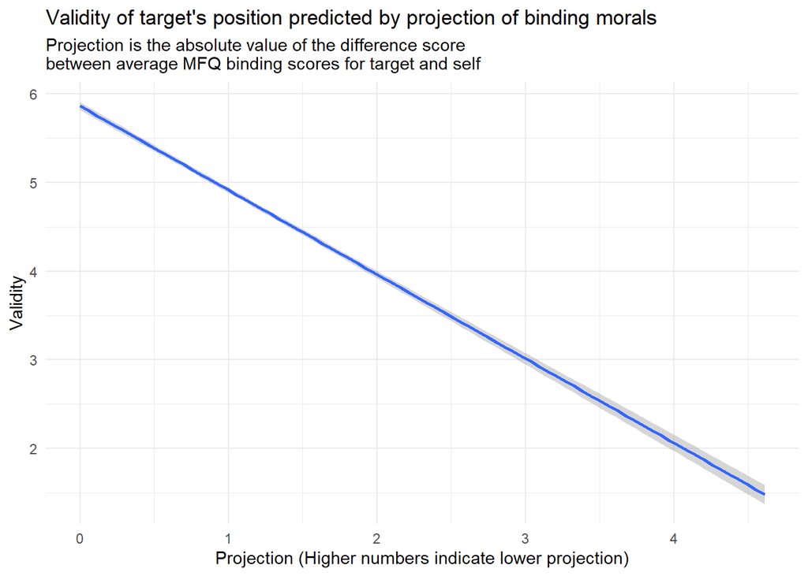

```r
#main effect of projection
ggplot(mfq_binding_diff, aes(proj_bind_diff, Valid)) +
  geom_smooth(method = "lm") +
  theme_minimal() +
  labs(title = "Validity of target's position predicted by projection of binding morals",
       subtitle = "Projection is the absolute value of the difference score \nbetween average MFQ binding scores for target and self",
       x = "Projection (Higher numbers indicate lower projection)",
       y = "Validity")
```

As counter projection of binding morals increases, validity decreases.

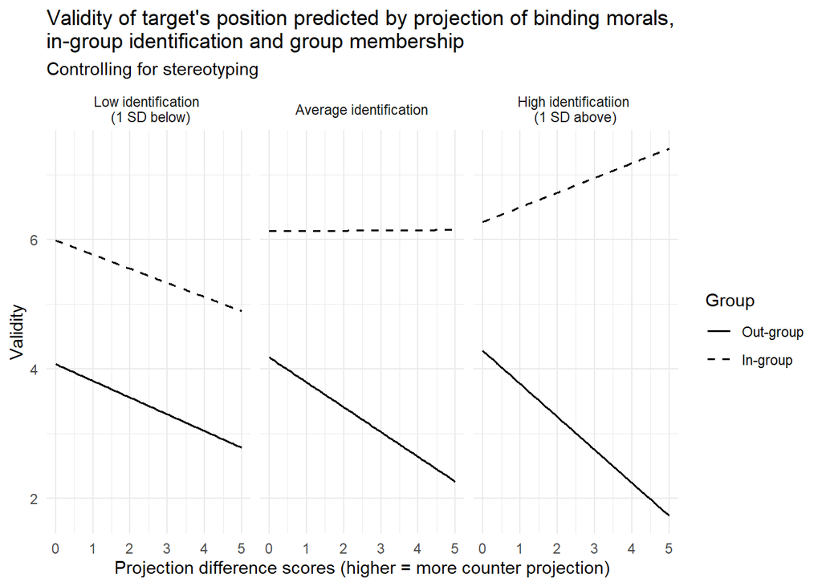

```r
valid_bind_3way <- effect(term = "proj_bind_diff:inoutgroup_effects:ident_c",
                           xlevels = list(ident_c = c(-1.78, 0, 1.78),
                                         inoutgroup_effects = c(-.5,.5)),
                           mod = valid_bind)

valid_bind_3way <- as.data.frame(valid_bind_3way)

valid_bind_3way$Group <- as.factor(valid_bind_3way$inoutgroup_effects)
valid_bind_3way$Identification <- as.factor(valid_bind_3way$ident_c)

ident_label <- c("-1.78" = "Low identification \n (1 SD below)",
                 "0" = "Average identification",
                 "1.78" = "High identificatiion \n(1 SD above)")


#three-way interaction
ggplot(valid_bind_3way, aes(proj_bind_diff,
                             fit,
                             group = Group,
                             color = Group)) +
  geom_smooth(method = "lm", se = FALSE, size = .7, colour = "black",
              aes(linetype = Group)) +
  facet_wrap(~Identification, labeller =
               labeller(Identification = ident_label)) +
  scale_linetype_manual("Group", breaks = c(-.5, .5),
                       labels = c("Out-group", "In-group"),
                       values = c("solid",
                                   "dashed")) +
  theme_minimal() +
  labs(title = "Validity of target's position predicted by projection of binding morals, \nin-group identification and group membership",
       subtitle = "Controlling for stereotyping",
       x = "Projection difference scores (higher = more counter projection)",
       y = "Validity")
```

For those who weakly identify with their in-group, people report higher validity for their in-group than their out-group, but, as counter projection increases, validity for both groups decreases by a similar amount. For people who report average identification with their in-group, they report higher validity for their in-group than their out-group and, as counter projection increases, validity for the in-group does not change, while validity for the out-group decreases. For those who highly identify with their in-group, people report higher validity for their in-group than their out-group and, as counter projection increases, validity for the in-group increases, while validity to the out-group decreases to the lowest reported validity of all conditions.

### Individuating model

```r
valid_indiv <- lm(Valid  ~ proj_indiv_diff*stereo_indiv_diff*inoutgroup_effects*ident_c, mfq_individual_diff)
summary(valid_indiv)
```

```
##
## Call:
## lm(formula = Valid ~ proj_indiv_diff * stereo_indiv_diff * inoutgroup_effects *
##     ident_c, data = mfq_individual_diff)
##
## Residuals:
##     Min      1Q  Median      3Q     Max
## -4.1614 -0.9591  0.0237  0.8485  4.9006
##
## Coefficients: (4 not defined because of singularities)
##                                                              Estimate
## (Intercept)                                                   5.11705
## proj_indiv_diff                                               0.05548
## stereo_indiv_diff                                                  NA
## inoutgroup_effects                                            1.92719
## ident_c                                                       0.06032
## proj_indiv_diff:stereo_indiv_diff                            -0.22667
## proj_indiv_diff:inoutgroup_effects                            0.93074
## stereo_indiv_diff:inoutgroup_effects                               NA
## proj_indiv_diff:ident_c                                      -0.02078
## stereo_indiv_diff:ident_c                                          NA
## inoutgroup_effects:ident_c                                    0.18797
## proj_indiv_diff:stereo_indiv_diff:inoutgroup_effects         -0.38056
## proj_indiv_diff:stereo_indiv_diff:ident_c                     0.06001
## proj_indiv_diff:inoutgroup_effects:ident_c                   -0.22630
## stereo_indiv_diff:inoutgroup_effects:ident_c                       NA
## proj_indiv_diff:stereo_indiv_diff:inoutgroup_effects:ident_c  0.17629
##                                                              Std. Error t value
## (Intercept)                                                     0.03469 147.488
## proj_indiv_diff                                                 0.07864   0.706
## stereo_indiv_diff                                                    NA      NA
## inoutgroup_effects                                              0.06939  27.773
## ident_c                                                         0.01719   3.509
## proj_indiv_diff:stereo_indiv_diff                               0.04223  -5.368
## proj_indiv_diff:inoutgroup_effects                              0.15727   5.918
## stereo_indiv_diff:inoutgroup_effects                                 NA      NA
## proj_indiv_diff:ident_c                                         0.03956  -0.525
## stereo_indiv_diff:ident_c                                            NA      NA
## inoutgroup_effects:ident_c                                      0.03438   5.467
## proj_indiv_diff:stereo_indiv_diff:inoutgroup_effects            0.08445  -4.506
```

[output cut: 29 more lines]

```
## stereo_indiv_diff:inoutgroup_effects
## proj_indiv_diff:ident_c
## stereo_indiv_diff:ident_c
## inoutgroup_effects:ident_c                                   ***
## proj_indiv_diff:stereo_indiv_diff:inoutgroup_effects         ***
## proj_indiv_diff:stereo_indiv_diff:ident_c                    **
## proj_indiv_diff:inoutgroup_effects:ident_c                   **
## stereo_indiv_diff:inoutgroup_effects:ident_c
## proj_indiv_diff:stereo_indiv_diff:inoutgroup_effects:ident_c ***
## ---
## Signif. codes:  0 '***' 0.001 '**' 0.01 '*' 0.05 '.' 0.1 ' ' 1
##
## Residual standard error: 1.389 on 7944 degrees of freedom
## Multiple R-squared:  0.507,  Adjusted R-squared:  0.5063
## F-statistic: 742.8 on 11 and 7944 DF,  p-value: < 0.00000000000000022
```

# Look at downstream effects with coefficients from lmer model per person

## Liking

### Overall

```r
liking_coeff <- lm(Liking ~ MFQSelf_c*`MFQSelf_c:inoutgroup_effects`*`MFQSelf_c:ident_c`*`MFQSelf_c:inoutgroup_effects:ident_c`, data = downstream_coeffs)

summary(liking_coeff)
```

```
##
## Call:
## lm(formula = Liking ~ MFQSelf_c * `MFQSelf_c:inoutgroup_effects` *
##     `MFQSelf_c:ident_c` * `MFQSelf_c:inoutgroup_effects:ident_c`,
##     data = downstream_coeffs)
##
## Residuals:
##     Min      1Q  Median      3Q     Max
## -3.8717 -1.0608 -0.0654  1.2492  3.3006
##
## Coefficients: (14 not defined because of singularities)
##                                                                                                     Estimate
## (Intercept)                                                                                          4.21564
## MFQSelf_c                                                                                            2.11040
## `MFQSelf_c:inoutgroup_effects`                                                                            NA
## `MFQSelf_c:ident_c`                                                                                       NA
## `MFQSelf_c:inoutgroup_effects:ident_c`                                                                    NA
## MFQSelf_c:`MFQSelf_c:inoutgroup_effects`                                                                  NA
## MFQSelf_c:`MFQSelf_c:ident_c`                                                                             NA
## `MFQSelf_c:inoutgroup_effects`:`MFQSelf_c:ident_c`                                                        NA
## MFQSelf_c:`MFQSelf_c:inoutgroup_effects:ident_c`                                                          NA
## `MFQSelf_c:inoutgroup_effects`:`MFQSelf_c:inoutgroup_effects:ident_c`                                     NA
## `MFQSelf_c:ident_c`:`MFQSelf_c:inoutgroup_effects:ident_c`                                                NA
## MFQSelf_c:`MFQSelf_c:inoutgroup_effects`:`MFQSelf_c:ident_c`                                              NA
## MFQSelf_c:`MFQSelf_c:inoutgroup_effects`:`MFQSelf_c:inoutgroup_effects:ident_c`                           NA
## MFQSelf_c:`MFQSelf_c:ident_c`:`MFQSelf_c:inoutgroup_effects:ident_c`                                      NA
## `MFQSelf_c:inoutgroup_effects`:`MFQSelf_c:ident_c`:`MFQSelf_c:inoutgroup_effects:ident_c`                 NA
## MFQSelf_c:`MFQSelf_c:inoutgroup_effects`:`MFQSelf_c:ident_c`:`MFQSelf_c:inoutgroup_effects:ident_c`       NA
##                                                                                                     Std. Error
## (Intercept)                                                                                            0.07003
## MFQSelf_c                                                                                              0.24147
## `MFQSelf_c:inoutgroup_effects`                                                                              NA
## `MFQSelf_c:ident_c`                                                                                         NA
## `MFQSelf_c:inoutgroup_effects:ident_c`                                                                      NA
## MFQSelf_c:`MFQSelf_c:inoutgroup_effects`                                                                    NA
## MFQSelf_c:`MFQSelf_c:ident_c`                                                                               NA
## `MFQSelf_c:inoutgroup_effects`:`MFQSelf_c:ident_c`                                                          NA
## MFQSelf_c:`MFQSelf_c:inoutgroup_effects:ident_c`                                                            NA
## `MFQSelf_c:inoutgroup_effects`:`MFQSelf_c:inoutgroup_effects:ident_c`                                       NA
## `MFQSelf_c:ident_c`:`MFQSelf_c:inoutgroup_effects:ident_c`                                                  NA
```

[output cut: 48 more lines]

```
## MFQSelf_c:`MFQSelf_c:inoutgroup_effects:ident_c`
## `MFQSelf_c:inoutgroup_effects`:`MFQSelf_c:inoutgroup_effects:ident_c`
## `MFQSelf_c:ident_c`:`MFQSelf_c:inoutgroup_effects:ident_c`
## MFQSelf_c:`MFQSelf_c:inoutgroup_effects`:`MFQSelf_c:ident_c`
## MFQSelf_c:`MFQSelf_c:inoutgroup_effects`:`MFQSelf_c:inoutgroup_effects:ident_c`
## MFQSelf_c:`MFQSelf_c:ident_c`:`MFQSelf_c:inoutgroup_effects:ident_c`
## `MFQSelf_c:inoutgroup_effects`:`MFQSelf_c:ident_c`:`MFQSelf_c:inoutgroup_effects:ident_c`
## MFQSelf_c:`MFQSelf_c:inoutgroup_effects`:`MFQSelf_c:ident_c`:`MFQSelf_c:inoutgroup_effects:ident_c`
## ---
## Signif. codes:  0 '***' 0.001 '**' 0.01 '*' 0.05 '.' 0.1 ' ' 1
##
## Residual standard error: 1.576 on 667 degrees of freedom
##   (5 observations deleted due to missingness)
## Multiple R-squared:  0.1028, Adjusted R-squared:  0.1014
## F-statistic: 76.39 on 1 and 667 DF,  p-value: < 0.00000000000000022
```

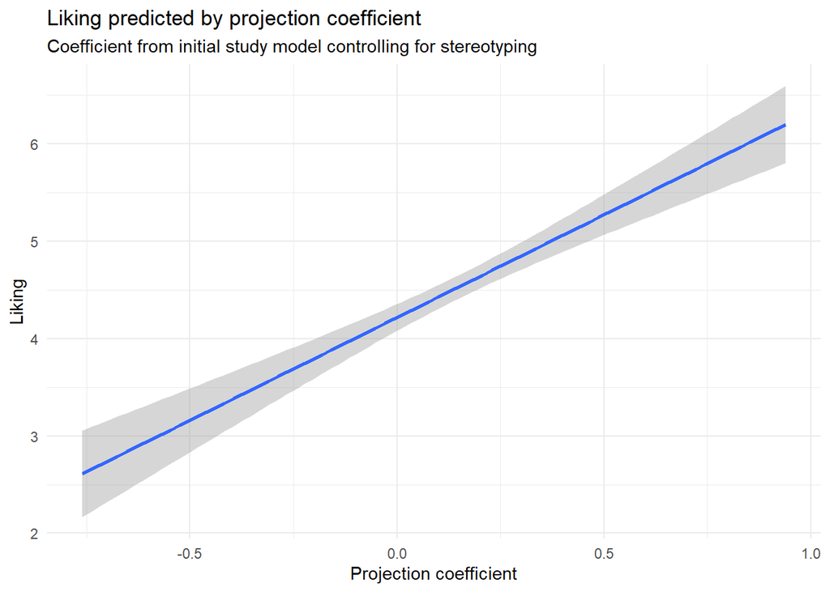

```r
ggplot(downstream_coeffs,aes(MFQSelf_c, Liking)) +
  geom_smooth(method = "lm") +
  labs(title = "Liking predicted by projection coefficient",
       subtitle = "Coefficient from initial study model controlling for stereotyping",
       x = "Projection coefficient") +
  theme_minimal()
```

### Liking including similiarity difference scores

```r
diffs <- downstream_analysis %>%
  select(subid, proj_diff, stereo_diff)

coeffs_and_diffs <- left_join(downstream_coeffs, diffs) %>%  unique()

liking_codiff <- lm(Liking ~ MFQSelf_c*proj_diff, coeffs_and_diffs)
summary(liking_codiff)
```

```
##
## Call:
## lm(formula = Liking ~ MFQSelf_c * proj_diff, data = coeffs_and_diffs)
##
## Residuals:
##     Min      1Q  Median      3Q     Max
## -4.0886 -1.0369  0.0241  1.1853  3.9471
##
## Coefficients:
##                     Estimate Std. Error t value             Pr(>|t|)
## (Intercept)           4.6136     0.1144  40.334 < 0.0000000000000002 ***
## MFQSelf_c             1.8815     0.3948   4.765           0.00000232 ***
## proj_diff            -0.6135     0.1292  -4.748           0.00000252 ***
## MFQSelf_c:proj_diff  -0.1288     0.5037  -0.256                0.798
## ---
## Signif. codes:  0 '***' 0.001 '**' 0.01 '*' 0.05 '.' 0.1 ' ' 1
##
## Residual standard error: 1.546 on 665 degrees of freedom
##   (5 observations deleted due to missingness)
## Multiple R-squared:  0.1397, Adjusted R-squared:  0.1358
## F-statistic: 35.99 on 3 and 665 DF,  p-value: < 0.00000000000000022
```

Two main effects but no interaction for liking. By the negative coefficient for the similarity score, we can tell that as dissimilarity increases, liking decreases (like the plot we did for the downstream effects using difference scores before).

### Liking with binding model coefficients

```r
#getting the coefficients from initial study with stereotyping
is_mfqbinding <- lmer(MFQTarg ~ MFQSelf_c * MFQStereo_c *
                                    inoutgroup_effects * ident_c +
                                    (MFQSelf_c|subid),
                                 data = mfq_binding)

coeffs_bind <- coef(is_mfqbinding)$subid

subid <- rownames(coeffs_bind)

coeffs_bind <- cbind(id = subid, coeffs_bind)

coeffs_bind <- coeffs_bind %>% mutate(subid = as.numeric(id))

downstream_coeffs_bind <- left_join(coeffs_bind, tomerge) %>% select(-id) %>% unique()
```

```r
liking_coeff_bind <- lm(Liking ~ MFQSelf_c*`MFQSelf_c:inoutgroup_effects`*`MFQSelf_c:ident_c`*`MFQSelf_c:inoutgroup_effects:ident_c`, data = downstream_coeffs_bind)
summary(liking_coeff_bind)
```

```
##
## Call:
## lm(formula = Liking ~ MFQSelf_c * `MFQSelf_c:inoutgroup_effects` *
##     `MFQSelf_c:ident_c` * `MFQSelf_c:inoutgroup_effects:ident_c`,
##     data = downstream_coeffs_bind)
##
## Residuals:
##     Min      1Q  Median      3Q     Max
## -4.0808 -0.9415 -0.1127  1.3590  3.2279
##
## Coefficients: (14 not defined because of singularities)
##                                                                                                     Estimate
## (Intercept)                                                                                          4.23230
## MFQSelf_c                                                                                            2.26496
## `MFQSelf_c:inoutgroup_effects`                                                                            NA
## `MFQSelf_c:ident_c`                                                                                       NA
## `MFQSelf_c:inoutgroup_effects:ident_c`                                                                    NA
## MFQSelf_c:`MFQSelf_c:inoutgroup_effects`                                                                  NA
## MFQSelf_c:`MFQSelf_c:ident_c`                                                                             NA
## `MFQSelf_c:inoutgroup_effects`:`MFQSelf_c:ident_c`                                                        NA
## MFQSelf_c:`MFQSelf_c:inoutgroup_effects:ident_c`                                                          NA
## `MFQSelf_c:inoutgroup_effects`:`MFQSelf_c:inoutgroup_effects:ident_c`                                     NA
## `MFQSelf_c:ident_c`:`MFQSelf_c:inoutgroup_effects:ident_c`                                                NA
## MFQSelf_c:`MFQSelf_c:inoutgroup_effects`:`MFQSelf_c:ident_c`                                              NA
## MFQSelf_c:`MFQSelf_c:inoutgroup_effects`:`MFQSelf_c:inoutgroup_effects:ident_c`                           NA
## MFQSelf_c:`MFQSelf_c:ident_c`:`MFQSelf_c:inoutgroup_effects:ident_c`                                      NA
## `MFQSelf_c:inoutgroup_effects`:`MFQSelf_c:ident_c`:`MFQSelf_c:inoutgroup_effects:ident_c`                 NA
## MFQSelf_c:`MFQSelf_c:inoutgroup_effects`:`MFQSelf_c:ident_c`:`MFQSelf_c:inoutgroup_effects:ident_c`       NA
##                                                                                                     Std. Error
## (Intercept)                                                                                            0.08132
## MFQSelf_c                                                                                              0.40960
## `MFQSelf_c:inoutgroup_effects`                                                                              NA
## `MFQSelf_c:ident_c`                                                                                         NA
## `MFQSelf_c:inoutgroup_effects:ident_c`                                                                      NA
## MFQSelf_c:`MFQSelf_c:inoutgroup_effects`                                                                    NA
## MFQSelf_c:`MFQSelf_c:ident_c`                                                                               NA
## `MFQSelf_c:inoutgroup_effects`:`MFQSelf_c:ident_c`                                                          NA
## MFQSelf_c:`MFQSelf_c:inoutgroup_effects:ident_c`                                                            NA
## `MFQSelf_c:inoutgroup_effects`:`MFQSelf_c:inoutgroup_effects:ident_c`                                       NA
## `MFQSelf_c:ident_c`:`MFQSelf_c:inoutgroup_effects:ident_c`                                                  NA
```

[output cut: 47 more lines]

```
## `MFQSelf_c:inoutgroup_effects`:`MFQSelf_c:ident_c`
## MFQSelf_c:`MFQSelf_c:inoutgroup_effects:ident_c`
## `MFQSelf_c:inoutgroup_effects`:`MFQSelf_c:inoutgroup_effects:ident_c`
## `MFQSelf_c:ident_c`:`MFQSelf_c:inoutgroup_effects:ident_c`
## MFQSelf_c:`MFQSelf_c:inoutgroup_effects`:`MFQSelf_c:ident_c`
## MFQSelf_c:`MFQSelf_c:inoutgroup_effects`:`MFQSelf_c:inoutgroup_effects:ident_c`
## MFQSelf_c:`MFQSelf_c:ident_c`:`MFQSelf_c:inoutgroup_effects:ident_c`
## `MFQSelf_c:inoutgroup_effects`:`MFQSelf_c:ident_c`:`MFQSelf_c:inoutgroup_effects:ident_c`
## MFQSelf_c:`MFQSelf_c:inoutgroup_effects`:`MFQSelf_c:ident_c`:`MFQSelf_c:inoutgroup_effects:ident_c`
## ---
## Signif. codes:  0 '***' 0.001 '**' 0.01 '*' 0.05 '.' 0.1 ' ' 1
##
## Residual standard error: 1.627 on 667 degrees of freedom
## Multiple R-squared:  0.04383,    Adjusted R-squared:  0.0424
## F-statistic: 30.58 on 1 and 667 DF,  p-value: 0.00000004608
```

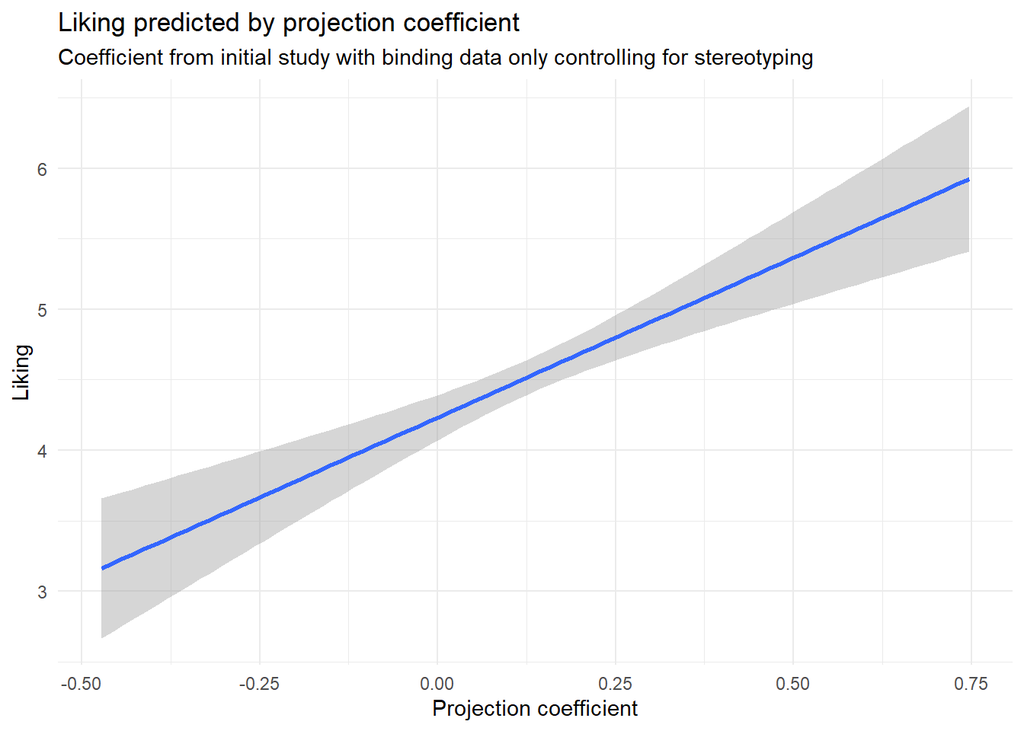

```r
ggplot(downstream_coeffs_bind,aes(MFQSelf_c, Liking)) +
  geom_smooth(method = "lm") +
  labs(title = "Liking predicted by projection coefficient",
       subtitle = "Coefficient from initial study with binding data only controlling for stereotyping",
       x = "Projection coefficient") +
  theme_minimal()
```

This looks pretty much the same as the overall model

### Liking with individuating model coefficients

```r
liking_coeff_indiv <- lm(Liking ~ MFQSelf_c*`MFQSelf_c:inoutgroup_effects`*`MFQSelf_c:ident_c`*`MFQSelf_c:inoutgroup_effects:ident_c`, data = downstream_coeffs_indiv)
summary(liking_coeff_indiv)
```

```
##
## Call:
## lm(formula = Liking ~ MFQSelf_c * `MFQSelf_c:inoutgroup_effects` *
##     `MFQSelf_c:ident_c` * `MFQSelf_c:inoutgroup_effects:ident_c`,
##     data = downstream_coeffs_indiv)
##
## Residuals:
##     Min      1Q  Median      3Q     Max
## -4.0738 -0.8740 -0.1002  1.3210  3.1777
##
## Coefficients: (14 not defined because of singularities)
##                                                                                                     Estimate
## (Intercept)                                                                                          4.10544
## MFQSelf_c                                                                                            1.94964
## `MFQSelf_c:inoutgroup_effects`                                                                            NA
## `MFQSelf_c:ident_c`                                                                                       NA
## `MFQSelf_c:inoutgroup_effects:ident_c`                                                                    NA
## MFQSelf_c:`MFQSelf_c:inoutgroup_effects`                                                                  NA
## MFQSelf_c:`MFQSelf_c:ident_c`                                                                             NA
## `MFQSelf_c:inoutgroup_effects`:`MFQSelf_c:ident_c`                                                        NA
## MFQSelf_c:`MFQSelf_c:inoutgroup_effects:ident_c`                                                          NA
## `MFQSelf_c:inoutgroup_effects`:`MFQSelf_c:inoutgroup_effects:ident_c`                                     NA
## `MFQSelf_c:ident_c`:`MFQSelf_c:inoutgroup_effects:ident_c`                                                NA
## MFQSelf_c:`MFQSelf_c:inoutgroup_effects`:`MFQSelf_c:ident_c`                                              NA
## MFQSelf_c:`MFQSelf_c:inoutgroup_effects`:`MFQSelf_c:inoutgroup_effects:ident_c`                           NA
## MFQSelf_c:`MFQSelf_c:ident_c`:`MFQSelf_c:inoutgroup_effects:ident_c`                                      NA
## `MFQSelf_c:inoutgroup_effects`:`MFQSelf_c:ident_c`:`MFQSelf_c:inoutgroup_effects:ident_c`                 NA
## MFQSelf_c:`MFQSelf_c:inoutgroup_effects`:`MFQSelf_c:ident_c`:`MFQSelf_c:inoutgroup_effects:ident_c`       NA
##                                                                                                     Std. Error
## (Intercept)                                                                                            0.09869
## MFQSelf_c                                                                                              0.35985
## `MFQSelf_c:inoutgroup_effects`                                                                              NA
## `MFQSelf_c:ident_c`                                                                                         NA
## `MFQSelf_c:inoutgroup_effects:ident_c`                                                                      NA
## MFQSelf_c:`MFQSelf_c:inoutgroup_effects`                                                                    NA
## MFQSelf_c:`MFQSelf_c:ident_c`                                                                               NA
## `MFQSelf_c:inoutgroup_effects`:`MFQSelf_c:ident_c`                                                          NA
## MFQSelf_c:`MFQSelf_c:inoutgroup_effects:ident_c`                                                            NA
## `MFQSelf_c:inoutgroup_effects`:`MFQSelf_c:inoutgroup_effects:ident_c`                                       NA
## `MFQSelf_c:ident_c`:`MFQSelf_c:inoutgroup_effects:ident_c`                                                  NA
```

[output cut: 47 more lines]

```
## `MFQSelf_c:inoutgroup_effects`:`MFQSelf_c:ident_c`
## MFQSelf_c:`MFQSelf_c:inoutgroup_effects:ident_c`
## `MFQSelf_c:inoutgroup_effects`:`MFQSelf_c:inoutgroup_effects:ident_c`
## `MFQSelf_c:ident_c`:`MFQSelf_c:inoutgroup_effects:ident_c`
## MFQSelf_c:`MFQSelf_c:inoutgroup_effects`:`MFQSelf_c:ident_c`
## MFQSelf_c:`MFQSelf_c:inoutgroup_effects`:`MFQSelf_c:inoutgroup_effects:ident_c`
## MFQSelf_c:`MFQSelf_c:ident_c`:`MFQSelf_c:inoutgroup_effects:ident_c`
## `MFQSelf_c:inoutgroup_effects`:`MFQSelf_c:ident_c`:`MFQSelf_c:inoutgroup_effects:ident_c`
## MFQSelf_c:`MFQSelf_c:inoutgroup_effects`:`MFQSelf_c:ident_c`:`MFQSelf_c:inoutgroup_effects:ident_c`
## ---
## Signif. codes:  0 '***' 0.001 '**' 0.01 '*' 0.05 '.' 0.1 ' ' 1
##
## Residual standard error: 1.629 on 667 degrees of freedom
## Multiple R-squared:  0.04215,    Adjusted R-squared:  0.04072
## F-statistic: 29.35 on 1 and 667 DF,  p-value: 0.0000000843
```

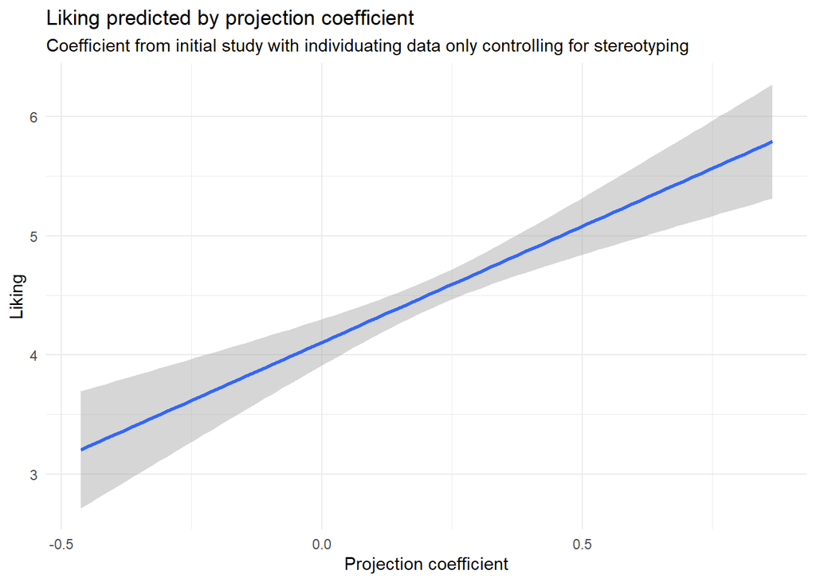

```r
ggplot(downstream_coeffs_indiv,aes(MFQSelf_c, Liking)) +
  geom_smooth(method = "lm") +
  labs(title = "Liking predicted by projection coefficient",
       subtitle = "Coefficient from initial study with individuating data only controlling for stereotyping",
       x = "Projection coefficient") +
  theme_minimal()
```

Also pretty much the same as the overall model

## Willingness to have discussion

```r
discuss_coeffs <- lm(WilltoDiscuss ~ MFQSelf_c*`MFQSelf_c:inoutgroup_effects`*`MFQSelf_c:ident_c`*`MFQSelf_c:inoutgroup_effects:ident_c`, data = downstream_coeffs)
summary(discuss_coeffs)
```

```
##
## Call:
## lm(formula = WilltoDiscuss ~ MFQSelf_c * `MFQSelf_c:inoutgroup_effects` *
##     `MFQSelf_c:ident_c` * `MFQSelf_c:inoutgroup_effects:ident_c`,
##     data = downstream_coeffs)
##
## Residuals:
##     Min      1Q  Median      3Q     Max
## -4.5085 -1.1812  0.2831  1.7153  2.6674
##
## Coefficients: (14 not defined because of singularities)
##                                                                                                     Estimate
## (Intercept)                                                                                          4.75088
## MFQSelf_c                                                                                            0.93792
## `MFQSelf_c:inoutgroup_effects`                                                                            NA
## `MFQSelf_c:ident_c`                                                                                       NA
## `MFQSelf_c:inoutgroup_effects:ident_c`                                                                    NA
## MFQSelf_c:`MFQSelf_c:inoutgroup_effects`                                                                  NA
## MFQSelf_c:`MFQSelf_c:ident_c`                                                                             NA
## `MFQSelf_c:inoutgroup_effects`:`MFQSelf_c:ident_c`                                                        NA
## MFQSelf_c:`MFQSelf_c:inoutgroup_effects:ident_c`                                                          NA
## `MFQSelf_c:inoutgroup_effects`:`MFQSelf_c:inoutgroup_effects:ident_c`                                     NA
## `MFQSelf_c:ident_c`:`MFQSelf_c:inoutgroup_effects:ident_c`                                                NA
## MFQSelf_c:`MFQSelf_c:inoutgroup_effects`:`MFQSelf_c:ident_c`                                              NA
## MFQSelf_c:`MFQSelf_c:inoutgroup_effects`:`MFQSelf_c:inoutgroup_effects:ident_c`                           NA
## MFQSelf_c:`MFQSelf_c:ident_c`:`MFQSelf_c:inoutgroup_effects:ident_c`                                      NA
## `MFQSelf_c:inoutgroup_effects`:`MFQSelf_c:ident_c`:`MFQSelf_c:inoutgroup_effects:ident_c`                 NA
## MFQSelf_c:`MFQSelf_c:inoutgroup_effects`:`MFQSelf_c:ident_c`:`MFQSelf_c:inoutgroup_effects:ident_c`       NA
##                                                                                                     Std. Error
## (Intercept)                                                                                            0.08478
## MFQSelf_c                                                                                              0.29231
## `MFQSelf_c:inoutgroup_effects`                                                                              NA
## `MFQSelf_c:ident_c`                                                                                         NA
## `MFQSelf_c:inoutgroup_effects:ident_c`                                                                      NA
## MFQSelf_c:`MFQSelf_c:inoutgroup_effects`                                                                    NA
## MFQSelf_c:`MFQSelf_c:ident_c`                                                                               NA
## `MFQSelf_c:inoutgroup_effects`:`MFQSelf_c:ident_c`                                                          NA
## MFQSelf_c:`MFQSelf_c:inoutgroup_effects:ident_c`                                                            NA
## `MFQSelf_c:inoutgroup_effects`:`MFQSelf_c:inoutgroup_effects:ident_c`                                       NA
## `MFQSelf_c:ident_c`:`MFQSelf_c:inoutgroup_effects:ident_c`                                                  NA
```

[output cut: 48 more lines]

```
## MFQSelf_c:`MFQSelf_c:inoutgroup_effects:ident_c`
## `MFQSelf_c:inoutgroup_effects`:`MFQSelf_c:inoutgroup_effects:ident_c`
## `MFQSelf_c:ident_c`:`MFQSelf_c:inoutgroup_effects:ident_c`
## MFQSelf_c:`MFQSelf_c:inoutgroup_effects`:`MFQSelf_c:ident_c`
## MFQSelf_c:`MFQSelf_c:inoutgroup_effects`:`MFQSelf_c:inoutgroup_effects:ident_c`
## MFQSelf_c:`MFQSelf_c:ident_c`:`MFQSelf_c:inoutgroup_effects:ident_c`
## `MFQSelf_c:inoutgroup_effects`:`MFQSelf_c:ident_c`:`MFQSelf_c:inoutgroup_effects:ident_c`
## MFQSelf_c:`MFQSelf_c:inoutgroup_effects`:`MFQSelf_c:ident_c`:`MFQSelf_c:inoutgroup_effects:ident_c`
## ---
## Signif. codes:  0 '***' 0.001 '**' 0.01 '*' 0.05 '.' 0.1 ' ' 1
##
## Residual standard error: 1.908 on 667 degrees of freedom
##   (5 observations deleted due to missingness)
## Multiple R-squared:  0.0152, Adjusted R-squared:  0.01372
## F-statistic:  10.3 on 1 and 667 DF,  p-value: 0.001398
```

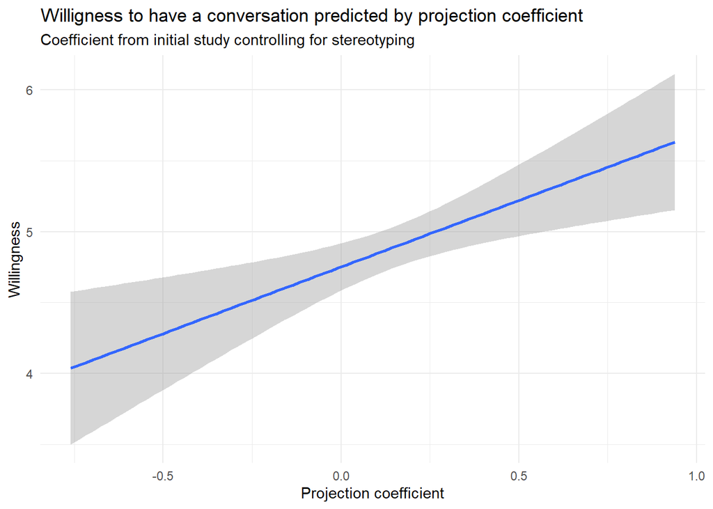

```r
ggplot(downstream_coeffs,aes(MFQSelf_c, WilltoDiscuss)) +
  geom_smooth(method = "lm") +
  labs(title = "Willigness to have a conversation predicted by projection coefficient",
       subtitle = "Coefficient from initial study controlling for stereotyping",
       x = "Projection coefficient",
       y = "Willingness") +
  theme_minimal()
```

### Willingness with difference scores too

```r
discuss_codiff <- lm(WilltoDiscuss ~ MFQSelf_c*proj_diff, coeffs_and_diffs)
summary(discuss_codiff)
```

```
##
## Call:
## lm(formula = WilltoDiscuss ~ MFQSelf_c * proj_diff, data = coeffs_and_diffs)
##
## Residuals:
##     Min      1Q  Median      3Q     Max
## -4.7063 -1.2055  0.3149  1.5950  3.4968
##
## Coefficients:
##                     Estimate Std. Error t value             Pr(>|t|)
## (Intercept)           5.0611     0.1395  36.281 < 0.0000000000000002 ***
## MFQSelf_c             1.1180     0.4815   2.322              0.02055 *
## proj_diff            -0.5069     0.1576  -3.217              0.00136 **
## MFQSelf_c:proj_diff  -0.7608     0.6143  -1.238              0.21601
## ---
## Signif. codes:  0 '***' 0.001 '**' 0.01 '*' 0.05 '.' 0.1 ' ' 1
##
## Residual standard error: 1.885 on 665 degrees of freedom
##   (5 observations deleted due to missingness)
## Multiple R-squared:  0.04166,    Adjusted R-squared:  0.03734
## F-statistic: 9.637 on 3 and 665 DF,  p-value: 0.00000311
```

Still significant after including the similarity scores, which, again, are also significant but the interaction between the two is not.